# River Radii Paper: Results display

Author

Francois Thoral

## 1 Introduction and Methods

This document shows the R code and data used to generate the figures for the paper Orchard et al. (2025).

We run Kruskall-Wallis on pair-wise comparisons (Wilcoxon rank sum tests with continuity correction) to look for significant differences in distribution of Kd490 and KdPAR values between classes and for each buffer sizes.

**Data used:**

- River names and river mouths location: `River Environmental Classification (REC2)` + Shane Orchard polish, January 2025 version.
- Coastal water clarity:
  - Downwelling light attenuation of PAR (400-700nm) coefficient (/m) (Gall et al. 2022), version 5, July 2002 to August 2023. [`https://gis.niwa.co.nz/portal/apps/experiencebuilder/template/?id=9794f29cd417493894df99d422c30ec2`](https://gis.niwa.co.nz/portal/apps/experiencebuilder/template/?id=9794f29cd417493894df99d422c30ec2).
  - Downwelling light attenuation at 490nm coefficient (/m) OC-CCI product, 4km resolution, https://www.oceancolour.org/thredds/ncss/grid/CCI_ALL-v6.0-DAILY/dataset.html, using QAA to calculate the IOPs, then Lee (2005) to get Kd490 from IOPs.

Table 1: River mouth hydrosystem original classes (left) and suggested new grouping (right)

**Classes**

Waituna-type lagoon

1. Open Coast

Hāpua-type lagoon

1. Open Coast

Beach streams

1. Open Coast

Freshwater river mouth

1. Open Coast

Tidal river mouth

1. Open Coast

Tidal lagoon

1. Open Coast

Shallow drowned valley

2. Enclosed Coast

Deep drowned valley

2. Enclosed Coast

Fjord

2. Enclosed Coast

## 2 Results

```r
library(tidyverse)
library(sf)
library(plotly)
library(viridis)
library(knitr)
library(broom)
library(DT)
library(ggpubr)
library(trend)
```

### 2.1 Figure 5 Kd490, KdPAR boxplot, all radii

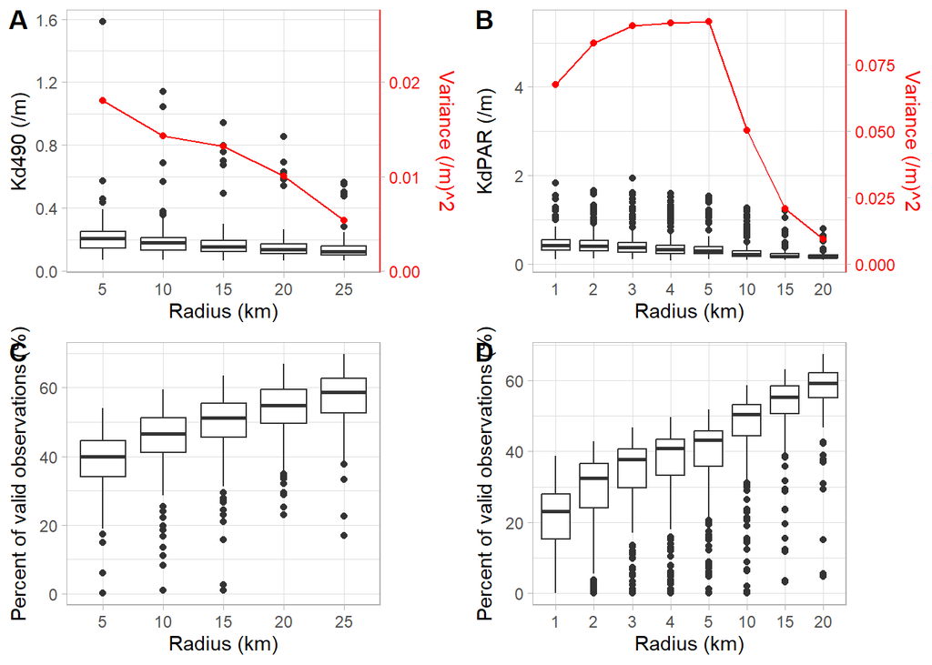

```r
kd_metrics <- read_csv('KdPAR_SCENZ_v05_Kd490_OCCCI_10yrMetrics_From_1D_AllBuffers_Rivermouths_REC2_class2.csv') %>%
      select(-CLASS,Interface)


rivermouth <- read_csv('REC2rivermouths_Order5-8_Reg_BioR_EcoD_HSclass_named.csv') %>%
  mutate(NAME_name2 = paste0(NAME,'_',name_2)) %>%
  select(NAME_name2,CLASS,BioR__BioR,CATCHMT_AR,REGC2017_N,StreamOrde,RID) %>%
  mutate(CLASS2 = case_when(
    CLASS == "2. Waituna-type lagoon" | CLASS == "3. Hāpua-type lagoon" | CLASS == "4. Beach stream" | CLASS == "5. Freshwater river mouth" | CLASS == "6. Tidal river mouth" | CLASS == "7. Tidal lagoon" ~ 'Open Coast',
    CLASS == "8. Shallow drowned valley" | CLASS == "9. Deep drowned valley" | CLASS == "10. Fjord" ~ 'Enclosed Coast',
    TRUE ~ 'NA')) %>%
    mutate(CLASS = case_when(
    CLASS == "2. Waituna-type lagoon" ~ "Waituna-type lagoon",
    CLASS == "3. Hāpua-type lagoon" ~ "Hāpua-type lagoon",
    CLASS == "4. Beach stream" ~ "Beach stream",
    CLASS == "5. Freshwater river mouth" ~ "Freshwater river mouth",
    CLASS == "6. Tidal river mouth" ~ "Tidal river mouth",
    CLASS == "7. Tidal lagoon" ~ 'Tidal lagoon',
    CLASS == "8. Shallow drowned valley" ~ "Shallow drowned valley",
    CLASS == "9. Deep drowned valley" ~ "Deep drowned valley",
    CLASS == "10. Fjord" ~ 'Fjord',
    TRUE ~ 'NA')) %>%
    mutate(CLASS = factor(CLASS, levels = c("Waituna-type lagoon",
                                          "Hāpua-type lagoon",
                                          "Beach stream",
                                          "Freshwater river mouth",
                                          "Tidal river mouth",
                                          "Tidal lagoon",
                                          "Shallow drowned valley",
                                          "Deep drowned valley",
                                          "Fjord")))

kd_metrics <- inner_join(kd_metrics,rivermouth)

kd_variance <- kd_metrics %>% group_by(Buffer_Size) %>%
  filter(Metrics == 'mean') %>%
  mutate(variance = var(KdPAR,na.rm=T),
         Buffer_Size = Buffer_Size/1000) %>%
  filter(!is.na(KdPAR))

ratio <- 15

p <- ggplot(data=kd_variance) +
  geom_boxplot(aes(x=factor(Buffer_Size),y=KdPAR)) +
  geom_path(aes(x= factor(Buffer_Size), y=variance*ratio), colour='red',group=1) +
  geom_point(aes(x= factor(Buffer_Size), y=variance*ratio), colour='red',group=1) +
  scale_y_continuous(
    name = "KdPAR (/m)",
    # Add a second axis and specify its features
    sec.axis = sec_axis(~ ./ratio, name="Variance (/m)^2")) +
  scale_fill_viridis_d() +
  xlab('Radius (km)') +
  theme_light() +
  theme(legend.position = 'bottom',
        axis.text.y.right = element_text(color = "red"),
        axis.line.y.right = element_line(color = "red"),
        axis.title.y.right = element_text(color = "red"))

kd_variance2 <- kd_metrics %>% group_by(Buffer_Size) %>%
  filter(Metrics == 'mean') %>%
  mutate(variance = var(Kd490,na.rm=T),
         Buffer_Size = Buffer_Size/1000) %>%
  filter(!is.na(Kd490))

ratio <- 60

p2 <- ggplot(data=kd_variance2) +
  geom_boxplot(aes(x=factor(Buffer_Size),y=Kd490)) +
  geom_path(aes(x= factor(Buffer_Size), y=variance*ratio), colour='red',group=1) +
  geom_point(aes(x= factor(Buffer_Size), y=variance*ratio), colour='red',group=1) +
  scale_y_continuous(
    name = "Kd490 (/m)",
    # Add a second axis and specify its features
    sec.axis = sec_axis(~ ./ratio, name="Variance (/m)^2")) +
  scale_fill_viridis_d() +
  xlab('Radius (km)') +
  theme_light() +
  theme(legend.position = 'bottom',
        axis.text.y.right = element_text(color = "red"),
        axis.line.y.right = element_line(color = "red"),
        axis.title.y.right = element_text(color = "red"))

p_obs <- kd_metrics %>%
  filter(Metrics == 'valid_days_pc') %>%
  filter(!is.na(KdPAR)) %>%
  mutate(Buffer_Size = Buffer_Size/1000) %>%
  ggplot(data=.,aes(x=factor(Buffer_Size),y=KdPAR)) +
  geom_boxplot() +
  scale_fill_viridis_d() +
  #ggtitle('Percentage of valid observations of KdPAR (2013-2022)') +
  ylab('Percent of valid observations (%)') + xlab('Radius (km)') +
  theme_light() +
  theme(legend.position = 'bottom')

p2_obs <- kd_metrics %>%
  filter(Metrics == 'valid_days_pc') %>%
  filter(!is.na(Kd490)) %>%
  mutate(Buffer_Size = Buffer_Size/1000) %>%
  ggplot(data=.,aes(x=factor(Buffer_Size),y=Kd490)) +
  geom_boxplot() +
  scale_fill_viridis_d() +
  #ggtitle('Percentage of valid observations of Kd490 (2013-2022)') +
  ylab('Percent of valid observations (%)') + xlab('Radius (km)') +
  theme_light() +
  theme(legend.position = 'bottom')

figure5 <- ggarrange(p2,
                     p,
                     p2_obs,
                     p_obs,
                     labels = c("A", "B","C","D"),
                     ncol = 2, nrow = 2, align = 'v')
figure5
```

### 2.2 KdPAR and Kd490 pairwise comparison

#### 2.2.1 KdPAR Pairwise comparison

```r
aa <-  kd_metrics %>%
  filter(!is.na(KdPAR)) %>%
  filter(Metrics == 'mean') %>%
  select(KdPAR,Buffer_Size) %>%
  mutate(Buffer_Size = Buffer_Size/1000)


pw <- pairwise.wilcox.test(aa$KdPAR,aa$Buffer_Size)

pw %>%
  tidy() %>%
  pivot_wider(names_from = c(group2),values_from = p.value) %>%
  DT::datatable() %>%
  DT::formatStyle(c('1',
                    '2',
                    '3',
                    '4',
                    '5',
                    '10',
                    '15'),target = 'cell',fontWeight = styleInterval(.05, c('bold', 'normal'))) %>%
  formatRound(c(2:8), 5) %>%
  formatStyle(columns = c(1:8), 'text-align' = 'center')
```

|  | group1 | 1 | 2 | 3 | 4 | 5 | 10 | 15 |
| --- | --- | --- | --- | --- | --- | --- | --- | --- |
| 1 | 2 | 0.2606703748745097 |  |  |  |  |  |  |
| 2 | 3 | 0.007191890843383723 | 0.0928377954669771 |  |  |  |  |  |
| 3 | 4 | 1.741063186205813e-06 | 0.0001790682752126356 | 0.0928377954669771 |  |  |  |  |
| 4 | 5 | 4.459636660391612e-10 | 9.750621376731066e-08 | 0.0007410500262727464 | 0.1446515774592511 |  |  |  |
| 5 | 10 | 3.058531104803447e-27 | 3.717499120859562e-25 | 5.614165319654844e-19 | 1.666301771093675e-13 | 9.253485699187756e-10 |  |  |
| 6 | 15 | 3.827567521484642e-43 | 1.843484444574108e-41 | 2.997055942425023e-35 | 2.572370643178632e-29 | 1.839071855650174e-25 | 5.16758840074228e-06 |  |
| 7 | 20 | 3.070596273667264e-52 | 1.720697740100842e-51 | 8.911196526655533e-47 | 3.457798331720912e-41 | 5.61967655364139e-39 | 3.918940038386142e-17 | 0.0001234400099100226 |

#### 2.2.2 Kd490 Pairwise comparison

```r
aa2 <-  kd_metrics %>%
  filter(!is.na(Kd490)) %>%
  filter(Metrics == 'mean') %>%
  select(Kd490,Buffer_Size) %>%
  mutate(Buffer_Size = Buffer_Size/1000)


pw2 <- pairwise.wilcox.test(aa2$Kd490,aa2$Buffer_Size)

pw2 %>%
  tidy() %>%
  pivot_wider(names_from = c(group2),values_from = p.value) %>%
  DT::datatable() %>%
  DT::formatStyle(c('5',
                    '10',
                    '15',
                    '20'),target = 'cell',fontWeight = styleInterval(.05, c('bold', 'normal'))) %>%
  formatRound(c(2:5), 5) %>%
  formatStyle(columns = c(1:5), 'text-align' = 'center')
```

|  | group1 | 5 | 10 | 15 | 20 |
| --- | --- | --- | --- | --- | --- |
| 1 | 10 | 0.004834836733510739 |  |  |  |
| 2 | 15 | 1.531292539398805e-07 | 0.007786663463286573 |  |  |
| 3 | 20 | 5.382372995986214e-15 | 3.061214756729694e-08 | 0.004195284573673967 |  |
| 4 | 25 | 5.477046099156916e-22 | 7.275605859346688e-15 | 7.888272088668781e-08 | 0.009379448437784429 |

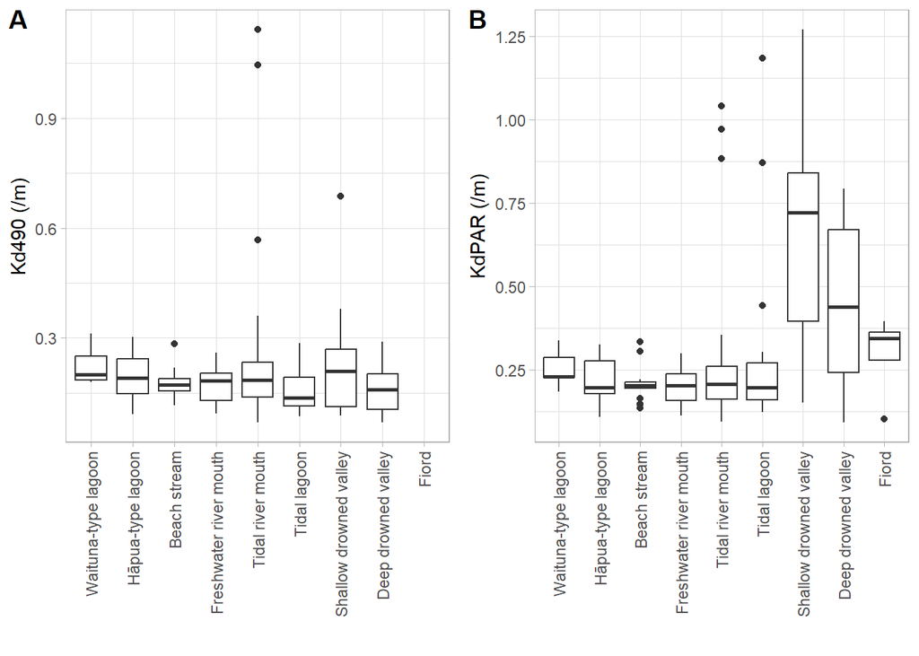

```r
p <- kd_metrics %>%
  mutate(CLASS = case_when(
    CLASS == "Fjord" ~ 'Fiord',
    TRUE ~ CLASS)) %>%
  mutate(CLASS = factor(CLASS, levels = c("Waituna-type lagoon",
                                          "Hāpua-type lagoon",
                                          "Beach stream",
                                          "Freshwater river mouth",
                                          "Tidal river mouth",
                                          "Tidal lagoon",
                                          "Shallow drowned valley",
                                          "Deep drowned valley",
                                          "Fiord"))) %>%
  filter(Buffer_Size == 10000 & Metrics == 'mean') %>%
  ggplot(data=.) +
  geom_boxplot(aes(x=factor(CLASS),y=KdPAR)) +
  scale_fill_viridis_d() +
  xlab('') +
  ylab('KdPAR (/m)') +
  theme_light() +
  theme(legend.position = 'bottom',
        axis.text.x = element_text(angle = 90, vjust = 0.5, hjust=1))


p2 <- kd_metrics %>%
    mutate(CLASS = case_when(
    CLASS == "Fjord" ~ 'Fiord',
    TRUE ~ CLASS)) %>%
    mutate(CLASS = factor(CLASS, levels = c("Waituna-type lagoon",
                                          "Hāpua-type lagoon",
                                          "Beach stream",
                                          "Freshwater river mouth",
                                          "Tidal river mouth",
                                          "Tidal lagoon",
                                          "Shallow drowned valley",
                                          "Deep drowned valley",
                                          "Fiord"))) %>%
  filter(Buffer_Size == 10000 & Metrics == 'mean') %>%
  ggplot(data=.) +
  geom_boxplot(aes(x=factor(CLASS),y=Kd490)) +
  scale_fill_viridis_d() +
  xlab('') +
  ylab('Kd490 (/m)') +
  theme_light() +
  theme(legend.position = 'bottom',
        axis.text.x = element_text(angle = 90, vjust = 0.5, hjust=1))

figure6 <- ggarrange(p2,
                     p,
                     labels = c("A", "B"),
                     ncol = 2, nrow = 1)
figure6
```

### 2.4 KdPAR and Kd490 summary per class, 10km radius, and pairwise comparison

```r
table2_kdPAR <- kd_metrics %>%
  filter(Buffer_Size == 10000 & Metrics == 'mean') %>%
  filter(!is.na(KdPAR)) %>%
  group_by(CLASS) %>%
  summarise(mean = mean(KdPAR,na.rm=T),
         sd = sd(KdPAR,na.rm=T),
         se = sd/sqrt(length(KdPAR)))

DT::datatable(table2_kdPAR) %>%
  formatRound(columns = c('mean','sd','se'), digits=3)
```

|  | CLASS | mean | sd | se |
| --- | --- | --- | --- | --- |
| 1 | Waituna-type lagoon | 0.2530167523946103 | 0.05764513281338617 | 0.02353352692462724 |
| 2 | Hāpua-type lagoon | 0.2203793412381735 | 0.0667736620543529 | 0.01363011669085065 |
| 3 | Beach stream | 0.2071645252039055 | 0.05042326809632992 | 0.01222943884411797 |
| 4 | Freshwater river mouth | 0.1990146938128234 | 0.04920688199057834 | 0.01073782197307546 |
| 5 | Tidal river mouth | 0.2446260379709769 | 0.1734558461809545 | 0.01892558440135336 |
| 6 | Tidal lagoon | 0.2563331805353823 | 0.207451637324629 | 0.03506572678706146 |
| 7 | Shallow drowned valley | 0.6710783839793519 | 0.3452893283525587 | 0.07534830875409818 |
| 8 | Deep drowned valley | 0.450472130938125 | 0.2677811742742867 | 0.08926039142476223 |
| 9 | Fjord | 0.2977810443733774 | 0.1318978035093235 | 0.06594890175466173 |

#### 2.4.1 KdPAR Pairwise comparison

```r
aa <- kd_metrics %>%
  filter(Buffer_Size == 10000 & Metrics == 'mean') %>%
  select(KdPAR,CLASS)

pw <- pairwise.wilcox.test(aa$KdPAR,aa$CLASS)

pw %>%
  tidy() %>%
  pivot_wider(names_from = c(group2),values_from = p.value) %>%
  DT::datatable() %>%
  DT::formatStyle(c('Waituna-type lagoon',
                    'Hāpua-type lagoon',
                    'Beach stream',
                    'Freshwater river mouth',
                    'Tidal river mouth',
                    'Tidal lagoon',
                    'Shallow drowned valley',
                    'Deep drowned valley'),target = 'cell',fontWeight = styleInterval(.05, c('bold', 'normal'))) %>%
  formatRound(c(2:9), 5) %>%
  formatStyle(columns = c(1:9), 'text-align' = 'center')
```

|  | group1 | Waituna-type lagoon | Hāpua-type lagoon | Beach stream | Freshwater river mouth | Tidal river mouth | Tidal lagoon | Shallow drowned valley | Deep drowned valley |
| --- | --- | --- | --- | --- | --- | --- | --- | --- | --- |
| 1 | Hāpua-type lagoon | 1 |  |  |  |  |  |  |  |
| 2 | Beach stream | 0.8360700768496869 | 1 |  |  |  |  |  |  |
| 3 | Freshwater river mouth | 1 | 1 | 1 |  |  |  |  |  |
| 4 | Tidal river mouth | 1 | 1 | 1 | 1 |  |  |  |  |
| 5 | Tidal lagoon | 1 | 1 | 1 | 1 | 1 |  |  |  |
| 6 | Shallow drowned valley | 0.1204396389243018 | 6.562604656210823e-05 | 0.0003893709343762257 | 6.75962866992672e-05 | 1.14215986887523e-06 | 9.099930306088115e-05 |  |  |
| 7 | Deep drowned valley | 1 | 0.8360700768496869 | 0.9079701076955081 | 0.8360700768496869 | 0.9320606346485545 | 1 | 1 |  |
| 8 | Fjord | 1 | 1 | 1 | 1 | 1 | 1 | 1 | 1 |

```r
table2_kd490 <- kd_metrics %>%
  filter(Buffer_Size == 10000 & Metrics == 'mean') %>%
  filter(!is.na(Kd490)) %>%
  group_by(CLASS) %>%
  summarise(mean = mean(Kd490,na.rm=T),
         sd = sd(Kd490,na.rm=T),
         se = sd/sqrt(length(Kd490)))

DT::datatable(table2_kd490) %>%
  formatRound(columns = c('mean','sd','se'), digits=3)
```

|  | CLASS | mean | sd | se |
| --- | --- | --- | --- | --- |
| 1 | Waituna-type lagoon | 0.223325783968718 | 0.05384114596793189 | 0.02198055579802351 |
| 2 | Hāpua-type lagoon | 0.1932669570637326 | 0.06371168703996478 | 0.01300509365831714 |
| 3 | Beach stream | 0.1714969748464941 | 0.04036394952842022 | 0.009789695727810396 |
| 4 | Freshwater river mouth | 0.1708687638106114 | 0.04637321357866437 | 0.01011946483059921 |
| 5 | Tidal river mouth | 0.2139447269306311 | 0.1613968931836654 | 0.01771561054494013 |
| 6 | Tidal lagoon | 0.1527545600827782 | 0.04798985052778513 | 0.008353960689541143 |
| 7 | Shallow drowned valley | 0.2403048040166675 | 0.1743791491799327 | 0.05257729173556793 |
| 8 | Deep drowned valley | 0.1637316595683682 | 0.08104422589363759 | 0.03308616667304469 |

#### 2.4.2 Kd490 Pairwise comparison

```r
aa2 <- kd_metrics %>%
  filter(Buffer_Size == 10000 & Metrics == 'mean') %>%
  select(Kd490,CLASS) %>% na.omit()

pw2 <- pairwise.wilcox.test(aa2$Kd490,aa2$CLASS)

pw2 %>%
  tidy() %>%
  pivot_wider(names_from = c(group2),values_from = p.value) %>%
  DT::datatable() %>%
  DT::formatStyle(c('Waituna-type lagoon',
                    'Hāpua-type lagoon',
                    'Beach stream',
                    'Freshwater river mouth',
                    'Tidal river mouth',
                    'Tidal lagoon',
                    'Shallow drowned valley'),
                  target = 'cell',fontWeight = styleInterval(.05, c('bold', 'normal'))) %>%
  formatRound(c(2:8), 5) %>%
  formatStyle(columns = c(1:8), 'text-align' = 'center')
```

|  | group1 | Waituna-type lagoon | Hāpua-type lagoon | Beach stream | Freshwater river mouth | Tidal river mouth | Tidal lagoon | Shallow drowned valley |
| --- | --- | --- | --- | --- | --- | --- | --- | --- |
| 1 | Hāpua-type lagoon | 1 |  |  |  |  |  |  |
| 2 | Beach stream | 0.404381694116465 | 1 |  |  |  |  |  |
| 3 | Freshwater river mouth | 1 | 1 | 1 |  |  |  |  |
| 4 | Tidal river mouth | 1 | 1 | 1 | 1 |  |  |  |
| 5 | Tidal lagoon | 0.404381694116465 | 0.404381694116465 | 1 | 1 | 0.2097767947284086 |  |  |
| 6 | Shallow drowned valley | 1 | 1 | 1 | 1 | 1 | 1 |  |
| 7 | Deep drowned valley | 1 | 1 | 1 | 1 | 1 | 1 | 1 |

### 2.5 Figure 7 Kd490 and KdPAR Boxplot, 10yr mean, 10km buffer, NEW grouping

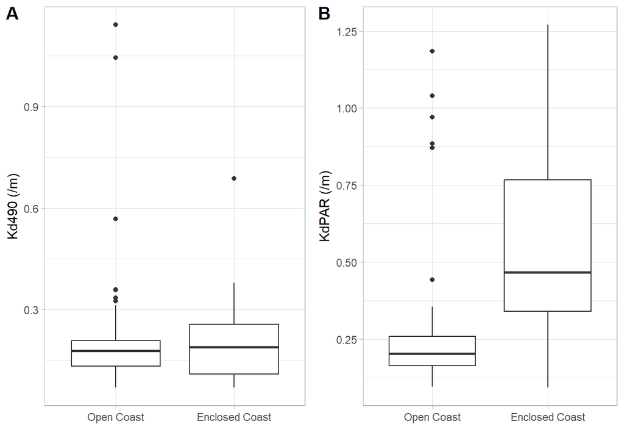

```r
p <- kd_metrics %>%
  mutate(CLASS2 = factor(CLASS2,levels = c('Open Coast','Enclosed Coast'))) %>%
  filter(Buffer_Size == 10000 & Metrics == 'mean') %>%
  ggplot(data=.) +
  geom_boxplot(aes(x=factor(CLASS2),y=KdPAR)) +
  scale_fill_viridis_d() +
  xlab('') +
  ylab('KdPAR (/m)') +
  theme_light() +
  theme(legend.position = 'bottom')

p2 <- kd_metrics %>%
  mutate(CLASS2 = factor(CLASS2,levels = c('Open Coast','Enclosed Coast'))) %>%
  filter(Buffer_Size == 10000 & Metrics == 'mean') %>%
  ggplot(data=.) +
  geom_boxplot(aes(x=factor(CLASS2),y=Kd490)) +
  scale_fill_viridis_d() +
  xlab('') +
  ylab('Kd490 (/m)') +
  theme_light() +
  theme(legend.position = 'bottom')#axis.text.x = element_text(angle = 90, vjust = 0.5, hjust=1)

figure7 <- ggarrange(p2,
                     p,
                     labels = c("A", "B"),
                     ncol = 2, nrow = 1)
figure7
```

#### 2.5.1 KdPAR Pairwise comparison

```r
aa <- kd_metrics %>%
  filter(Buffer_Size == 10000 & Metrics == 'mean') %>%
  select(KdPAR,CLASS2)

pw <- pairwise.wilcox.test(aa$KdPAR,aa$CLASS2)

pw %>%
  tidy() %>%
  pivot_wider(names_from = c(group2),values_from = p.value) %>%
  DT::datatable() %>%
  DT::formatStyle(c('Enclosed Coast'),target = 'cell',fontWeight = styleInterval(.05, c('bold', 'normal'))) %>%
  #formatRound(c(2), 5) %>%
  formatStyle(columns = c(1:2), 'text-align' = 'center')
```

|  | group1 | Enclosed Coast |
| --- | --- | --- |
| 1 | Open Coast | 7.850986490848137e-10 |

#### 2.5.2 Kd490 Pairwise comparison

```r
aa2 <- kd_metrics %>%
  filter(Buffer_Size == 10000 & Metrics == 'mean') %>%
  select(Kd490,CLASS2)

pw2 <- pairwise.wilcox.test(aa2$Kd490,aa2$CLASS2)

pw2 %>%
  tidy() %>%
  pivot_wider(names_from = c(group2),values_from = p.value) %>%
  DT::datatable() %>%
  DT::formatStyle(c('Enclosed Coast'),target = 'cell',fontWeight = styleInterval(.05, c('bold', 'normal'))) %>%
  formatRound(c(2), 3) %>%
  formatStyle(columns = c(1:2), 'text-align' = 'center')
```

|  | group1 | Enclosed Coast |
| --- | --- | --- |
| 1 | Open Coast | 0.9115151357975312 |

### 2.6 Figure 8 Does stream order influence KdPAR? Analysis of 6 metrics

##### 2.6.0.1 Main figure of case study

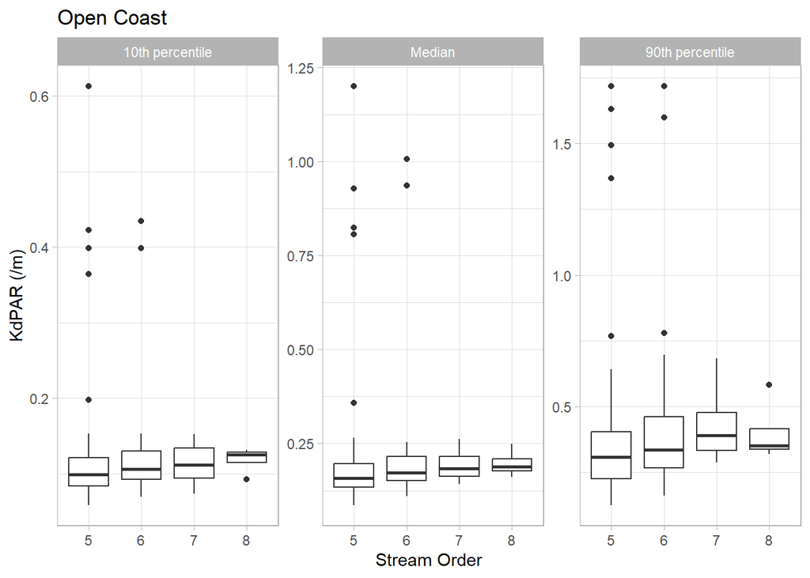

```r
p <- kd_metrics %>%
  mutate(Buffer_Size = Buffer_Size/1000) %>%
  filter(Buffer_Size == 10 & !is.na(KdPAR) & CLASS2 == "Open Coast" & Metrics %in% c('percentile10','median','percentile90')) %>%
  mutate(Metrics = case_when(Metrics == 'percentile10' ~  '10th percentile',
                             Metrics == 'median' ~  'Median',
                             Metrics == 'percentile90' ~  '90th percentile')) %>%
    mutate(Metrics = factor(Metrics,levels = c('percentile5','10th percentile','Median','90th percentile','percentile95'))) %>%
  ggplot(data=.,aes(x=factor(StreamOrde),y=KdPAR)) +
  geom_boxplot() +
  facet_wrap(~Metrics,ncol=3, scales = 'free') +
  scale_fill_viridis_d() +
  ylab('KdPAR (/m)') + xlab('Stream Order') +
  ggtitle("Open Coast") +
  theme_light() +
  theme(legend.position = 'bottom')
p
```

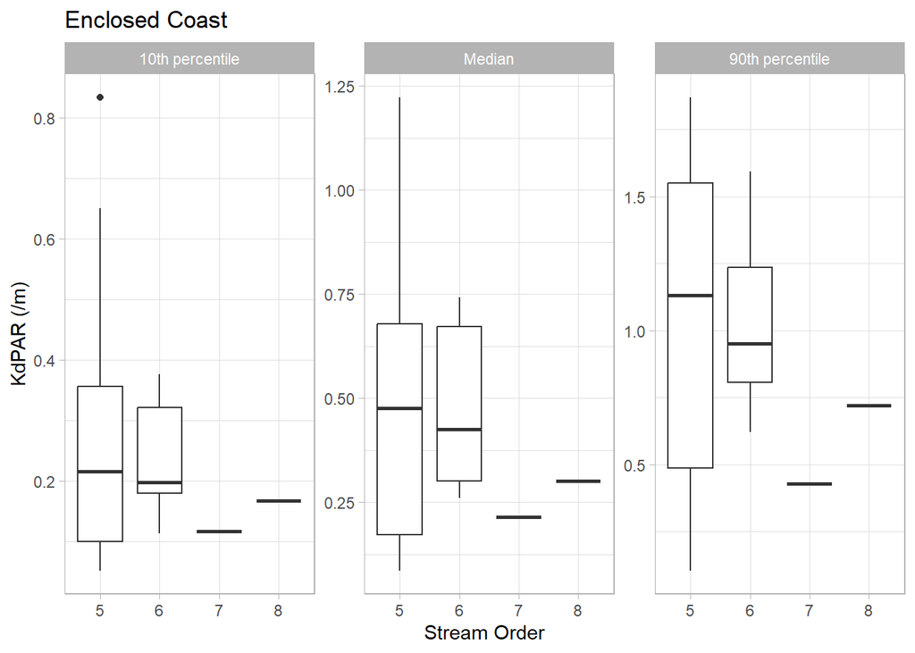

```r
p2 <- kd_metrics %>%
  mutate(Buffer_Size = Buffer_Size/1000) %>%
  filter(Buffer_Size == 10 & !is.na(KdPAR) & CLASS2 == "Enclosed Coast" & Metrics %in% c('percentile10','median','percentile90')) %>%
  mutate(Metrics = case_when(Metrics == 'percentile10' ~  '10th percentile',
                             Metrics == 'median' ~  'Median',
                             Metrics == 'percentile90' ~  '90th percentile')) %>%
    mutate(Metrics = factor(Metrics,levels = c('percentile5','10th percentile','Median','90th percentile','percentile95'))) %>%
  ggplot(data=.,aes(x=factor(StreamOrde),y=KdPAR)) +
  geom_boxplot() +
  facet_wrap(~Metrics,ncol=3, scales = 'free') +
  scale_fill_viridis_d() +
  ylab('KdPAR (/m)') + xlab('Stream Order') +
  ggtitle("Enclosed Coast") +
  theme_light() +
  theme(legend.position = 'bottom')
p2
```

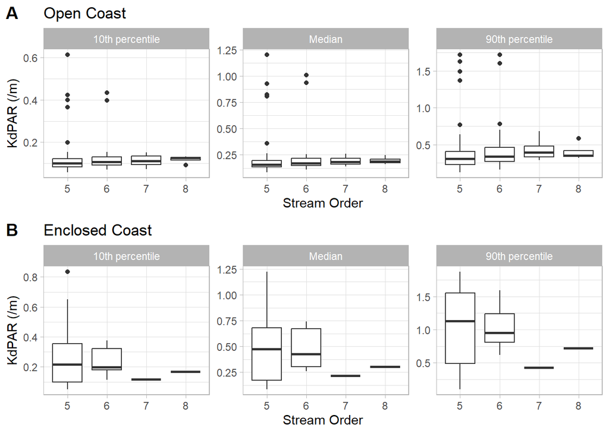

```r
figure8 <- ggarrange(p,
                     p2,
                     labels = c("A", "B"),
                     ncol = 1, nrow = 2)
figure8
```

##### 2.6.0.2 Percentile 5

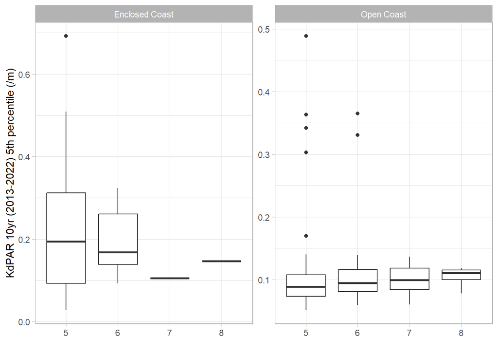

```r
p <- kd_metrics %>%
  mutate(Buffer_Size = Buffer_Size/1000) %>%
  filter(Buffer_Size == 10 & !is.na(KdPAR) & Metrics == 'percentile5') %>%
  ggplot(data=.,aes(x=factor(StreamOrde),y=KdPAR)) +
  geom_boxplot() +
  facet_wrap(~CLASS2,scales='free',ncol=2) +
  scale_fill_viridis_d() +
  ylab('KdPAR 10yr (2013-2022) 5th percentile (/m)') + xlab('') +
  theme_light() +
  theme(legend.position = 'bottom')
p
```

###### 2.6.0.2.1 Open Coast

```r
aa <- kd_metrics %>%
  filter(Buffer_Size == 10000 &
           Metrics == 'percentile5' &
         CLASS2 == 'Open Coast') %>%
  select(KdPAR,StreamOrde)

pw <- pairwise.wilcox.test(aa$KdPAR,aa$StreamOrde)

pw %>%
  tidy() %>%
  pivot_wider(names_from = c(group2),values_from = p.value) %>%
  DT::datatable() %>%
  DT::formatStyle(c('5', '6','7'),target = 'cell',fontWeight = styleInterval(.05, c('bold', 'normal'))) %>%
  #formatRound(c(2), 5) %>%
  formatStyle(columns = c(1:5), 'text-align' = 'center')
```

|  | group1 | 5 | 6 | 7 |
| --- | --- | --- | --- | --- |
| 1 | 6 | 0.3442686657756321 |  |  |
| 2 | 7 | 0.4564735287213285 | 1 |  |
| 3 | 8 | 0.9140537066431477 | 1 | 1 |

###### 2.6.0.2.2 Enclosed Coast

```r
aa <- kd_metrics %>%
  filter(Buffer_Size == 10000 &
           Metrics == 'percentile5' &
         CLASS2 == 'Enclosed Coast') %>%
  select(KdPAR,StreamOrde)

pw <- pairwise.wilcox.test(aa$KdPAR,aa$StreamOrde)

pw %>%
  tidy() %>%
  pivot_wider(names_from = c(group2),values_from = p.value) %>%
  DT::datatable() %>%
  DT::formatStyle(c('5', '6','7'),target = 'cell',fontWeight = styleInterval(.05, c('bold', 'normal'))) %>%
  #formatRound(c(2), 5) %>%
  formatStyle(columns = c(1:5), 'text-align' = 'center')
```

|  | group1 | 5 | 6 | 7 |
| --- | --- | --- | --- | --- |
| 1 | 6 | 1 |  |  |
| 2 | 7 | 1 | 1 |  |
| 3 | 8 | 1 | 1 | 1 |

##### 2.6.0.3 Percentile 10

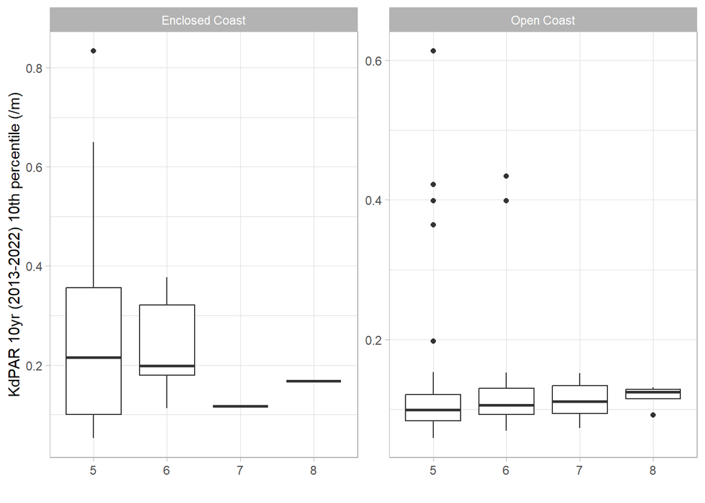

```r
p <- kd_metrics %>%
  mutate(Buffer_Size = Buffer_Size/1000) %>%
  filter(Buffer_Size == 10 & !is.na(KdPAR) & Metrics == 'percentile10') %>%
  ggplot(data=.,aes(x=factor(StreamOrde),y=KdPAR)) +
  geom_boxplot() +
  facet_wrap(~CLASS2,scales='free',ncol=2) +
  scale_fill_viridis_d() +
  ylab('KdPAR 10yr (2013-2022) 10th percentile (/m)') + xlab('') +
  theme_light() +
  theme(legend.position = 'bottom')
p
```

###### 2.6.0.3.1 Open Coast

```r
aa <- kd_metrics %>%
  filter(Buffer_Size == 10000 &
           Metrics == 'percentile10' &
         CLASS2 == 'Open Coast') %>%
  select(KdPAR,StreamOrde)

pw <- pairwise.wilcox.test(aa$KdPAR,aa$StreamOrde)

pw %>%
  tidy() %>%
  pivot_wider(names_from = c(group2),values_from = p.value) %>%
  DT::datatable() %>%
  DT::formatStyle(c('5', '6','7'),target = 'cell',fontWeight = styleInterval(.05, c('bold', 'normal'))) %>%
  #formatRound(c(2), 5) %>%
  formatStyle(columns = c(1:5), 'text-align' = 'center')
```

|  | group1 | 5 | 6 | 7 |
| --- | --- | --- | --- | --- |
| 1 | 6 | 0.3110177648399439 |  |  |
| 2 | 7 | 0.3110177648399439 | 1 |  |
| 3 | 8 | 0.602561271324917 | 1 | 1 |

###### 2.6.0.3.2 Enclosed Coast

```r
aa <- kd_metrics %>%
  filter(Buffer_Size == 10000 &
           Metrics == 'percentile10' &
         CLASS2 == 'Enclosed Coast') %>%
  select(KdPAR,StreamOrde)

pw <- pairwise.wilcox.test(aa$KdPAR,aa$StreamOrde)

pw %>%
  tidy() %>%
  pivot_wider(names_from = c(group2),values_from = p.value) %>%
  DT::datatable() %>%
  DT::formatStyle(c('5', '6','7'),target = 'cell',fontWeight = styleInterval(.05, c('bold', 'normal'))) %>%
  #formatRound(c(2), 5) %>%
  formatStyle(columns = c(1:5), 'text-align' = 'center')
```

|  | group1 | 5 | 6 | 7 |
| --- | --- | --- | --- | --- |
| 1 | 6 | 1 |  |  |
| 2 | 7 | 1 | 1 |  |
| 3 | 8 | 1 | 1 | 1 |

##### 2.6.0.4 Mean

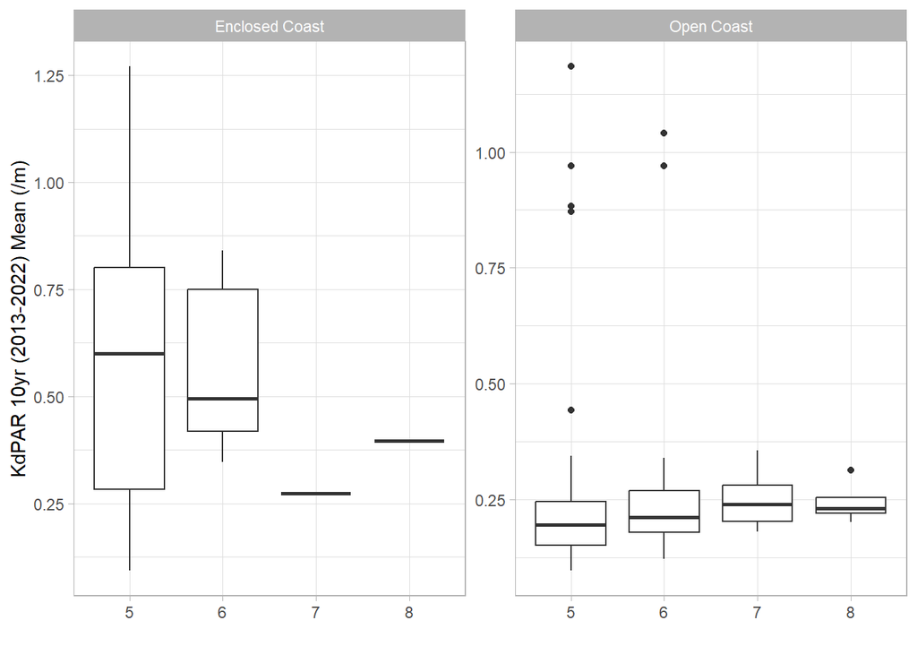

```r
p <- kd_metrics %>%
  mutate(Buffer_Size = Buffer_Size/1000) %>%
  filter(Buffer_Size == 10 & !is.na(KdPAR) & Metrics == 'mean') %>%
  ggplot(data=.,aes(x=factor(StreamOrde),y=KdPAR)) +
  geom_boxplot() +
  facet_wrap(~CLASS2,scales='free',ncol=2) +
  scale_fill_viridis_d() +
  ylab('KdPAR 10yr (2013-2022) Mean (/m)') + xlab('') +
  theme_light() +
  theme(legend.position = 'bottom')
p
```

###### 2.6.0.4.1 Open Coast

```r
aa <- kd_metrics %>%
  filter(Buffer_Size == 10000 &
           Metrics == 'mean' &
         CLASS2 == 'Open Coast') %>%
  select(KdPAR,StreamOrde)

pw <- pairwise.wilcox.test(aa$KdPAR,aa$StreamOrde)

pw %>%
  tidy() %>%
  pivot_wider(names_from = c(group2),values_from = p.value) %>%
  DT::datatable() %>%
  DT::formatStyle(c('5', '6','7'),target = 'cell',fontWeight = styleInterval(.05, c('bold', 'normal'))) %>%
  #formatRound(c(2), 5) %>%
  formatStyle(columns = c(1:5), 'text-align' = 'center')
```

|  | group1 | 5 | 6 | 7 |
| --- | --- | --- | --- | --- |
| 1 | 6 | 0.132265103100398 |  |  |
| 2 | 7 | 0.01440418938044651 | 0.5035795524973119 |  |
| 3 | 8 | 0.5035795524973119 | 0.7974952108994684 | 0.9700734048560136 |

###### 2.6.0.4.2 Enclosed Coast

```r
aa <- kd_metrics %>%
  filter(Buffer_Size == 10000 &
           Metrics == 'mean' &
         CLASS2 == 'Enclosed Coast') %>%
  select(KdPAR,StreamOrde)

pw <- pairwise.wilcox.test(aa$KdPAR,aa$StreamOrde)

pw %>%
  tidy() %>%
  pivot_wider(names_from = c(group2),values_from = p.value) %>%
  DT::datatable() %>%
  DT::formatStyle(c('5', '6','7'),target = 'cell',fontWeight = styleInterval(.05, c('bold', 'normal'))) %>%
  #formatRound(c(2), 5) %>%
  formatStyle(columns = c(1:5), 'text-align' = 'center')
```

|  | group1 | 5 | 6 | 7 |
| --- | --- | --- | --- | --- |
| 1 | 6 | 1 |  |  |
| 2 | 7 | 1 | 1 |  |
| 3 | 8 | 1 | 1 | 1 |

##### 2.6.0.5 Median

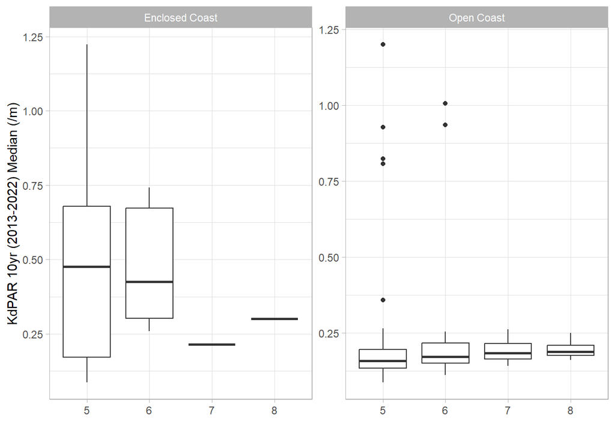

```r
p <- kd_metrics %>%
  mutate(Buffer_Size = Buffer_Size/1000) %>%
  filter(Buffer_Size == 10 & !is.na(KdPAR) & Metrics == 'median') %>%
  ggplot(data=.,aes(x=factor(StreamOrde),y=KdPAR)) +
  geom_boxplot() +
  facet_wrap(~CLASS2,scales='free',ncol=2) +
  scale_fill_viridis_d() +
  ylab('KdPAR 10yr (2013-2022) Median (/m)') + xlab('') +
  theme_light() +
  theme(legend.position = 'bottom')
p
```

###### 2.6.0.5.1 Open Coast

```r
aa <- kd_metrics %>%
  filter(Buffer_Size == 10000 &
           Metrics == 'median' &
         CLASS2 == 'Open Coast') %>%
  select(KdPAR,StreamOrde)

pw <- pairwise.wilcox.test(aa$KdPAR,aa$StreamOrde)

pw %>%
  tidy() %>%
  pivot_wider(names_from = c(group2),values_from = p.value) %>%
  DT::datatable() %>%
  DT::formatStyle(c('5', '6','7'),target = 'cell',fontWeight = styleInterval(.05, c('bold', 'normal'))) %>%
  #formatRound(c(2), 5) %>%
  formatStyle(columns = c(1:5), 'text-align' = 'center')
```

|  | group1 | 5 | 6 | 7 |
| --- | --- | --- | --- | --- |
| 1 | 6 | 0.1486504940266474 |  |  |
| 2 | 7 | 0.04278014388492278 | 0.6636989443338128 |  |
| 3 | 8 | 0.6204192661787936 | 0.6636989443338128 | 0.7940899680030115 |

###### 2.6.0.5.2 Enclosed Coast

```r
aa <- kd_metrics %>%
  filter(Buffer_Size == 10000 &
           Metrics == 'median' &
         CLASS2 == 'Enclosed Coast') %>%
  select(KdPAR,StreamOrde)

pw <- pairwise.wilcox.test(aa$KdPAR,aa$StreamOrde)

pw %>%
  tidy() %>%
  pivot_wider(names_from = c(group2),values_from = p.value) %>%
  DT::datatable() %>%
  DT::formatStyle(c('5', '6','7'),target = 'cell',fontWeight = styleInterval(.05, c('bold', 'normal'))) %>%
  #formatRound(c(2), 5) %>%
  formatStyle(columns = c(1:5), 'text-align' = 'center')
```

|  | group1 | 5 | 6 | 7 |
| --- | --- | --- | --- | --- |
| 1 | 6 | 1 |  |  |
| 2 | 7 | 1 | 1 |  |
| 3 | 8 | 1 | 1 | 1 |

##### 2.6.0.6 Percentile 90

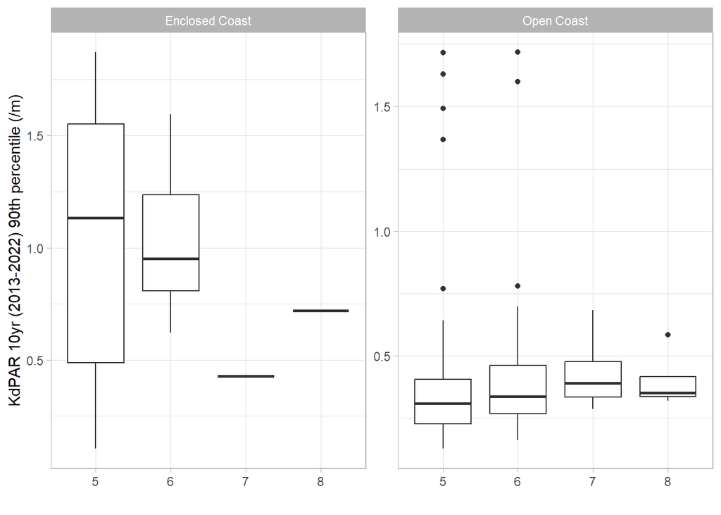

```r
p <- kd_metrics %>%
  mutate(Buffer_Size = Buffer_Size/1000) %>%
  filter(Buffer_Size == 10 & !is.na(KdPAR) & Metrics == 'percentile90') %>%
  ggplot(data=.,aes(x=factor(StreamOrde),y=KdPAR)) +
  geom_boxplot() +
  facet_wrap(~CLASS2,scales='free',ncol=2) +
  scale_fill_viridis_d() +
  ylab('KdPAR 10yr (2013-2022) 90th percentile (/m)') + xlab('') +
  theme_light() +
  theme(legend.position = 'bottom')
p
```

###### 2.6.0.6.1 Open Coast

```r
aa <- kd_metrics %>%
  filter(Buffer_Size == 10000 &
           Metrics == 'percentile90' &
         CLASS2 == 'Open Coast') %>%
  select(KdPAR,StreamOrde)

pw <- pairwise.wilcox.test(aa$KdPAR,aa$StreamOrde)

pw %>%
  tidy() %>%
  pivot_wider(names_from = c(group2),values_from = p.value) %>%
  DT::datatable() %>%
  DT::formatStyle(c('5', '6','7'),target = 'cell',fontWeight = styleInterval(.05, c('bold', 'normal'))) %>%
  #formatRound(c(2), 5) %>%
  formatStyle(columns = c(1:5), 'text-align' = 'center')
```

|  | group1 | 5 | 6 | 7 |
| --- | --- | --- | --- | --- |
| 1 | 6 | 0.1111292050675241 |  |  |
| 2 | 7 | 0.0106073640610683 | 0.5191357827732077 |  |
| 3 | 8 | 0.5191357827732077 | 1 | 1 |

###### 2.6.0.6.2 Enclosed Coast

```r
aa <- kd_metrics %>%
  filter(Buffer_Size == 10000 &
           Metrics == 'percentile90' &
         CLASS2 == 'Enclosed Coast') %>%
  select(KdPAR,StreamOrde)

pw <- pairwise.wilcox.test(aa$KdPAR,aa$StreamOrde)

pw %>%
  tidy() %>%
  pivot_wider(names_from = c(group2),values_from = p.value) %>%
  DT::datatable() %>%
  DT::formatStyle(c('5', '6','7'),target = 'cell',fontWeight = styleInterval(.05, c('bold', 'normal'))) %>%
  #formatRound(c(2), 5) %>%
  formatStyle(columns = c(1:5), 'text-align' = 'center')
```

|  | group1 | 5 | 6 | 7 |
| --- | --- | --- | --- | --- |
| 1 | 6 | 1 |  |  |
| 2 | 7 | 1 | 1 |  |
| 3 | 8 | 1 | 1 | 1 |

##### 2.6.0.7 Percentile 95

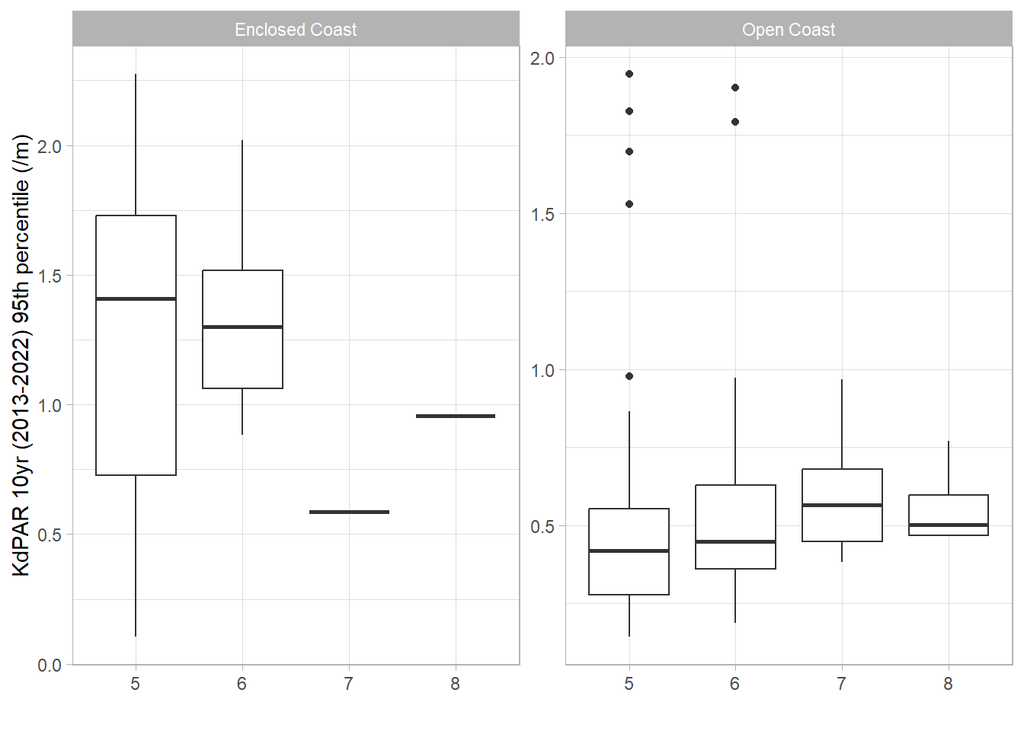

```r
p <- kd_metrics %>%
  mutate(Buffer_Size = Buffer_Size/1000) %>%
  filter(Buffer_Size == 10 & !is.na(KdPAR) & Metrics == 'percentile95') %>%
  ggplot(data=.,aes(x=factor(StreamOrde),y=KdPAR)) +
  geom_boxplot() +
  facet_wrap(~CLASS2,scales='free',ncol=2) +
  scale_fill_viridis_d() +
  ylab('KdPAR 10yr (2013-2022) 95th percentile (/m)') + xlab('') +
  theme_light() +
  theme(legend.position = 'bottom')
p
```

###### 2.6.0.7.1 Open Coast

```r
aa <- kd_metrics %>%
  filter(Buffer_Size == 10000 &
           Metrics == 'percentile95' &
         CLASS2 == 'Open Coast') %>%
  select(KdPAR,StreamOrde)

pw <- pairwise.wilcox.test(aa$KdPAR,aa$StreamOrde)

pw %>%
  tidy() %>%
  pivot_wider(names_from = c(group2),values_from = p.value) %>%
  DT::datatable() %>%
  DT::formatStyle(c('5', '6','7'),target = 'cell',fontWeight = styleInterval(.05, c('bold', 'normal'))) %>%
  #formatRound(c(2), 5) %>%
  formatStyle(columns = c(1:5), 'text-align' = 'center')
```

|  | group1 | 5 | 6 | 7 |
| --- | --- | --- | --- | --- |
| 1 | 6 | 0.165301387749349 |  |  |
| 2 | 7 | 0.004140669065179366 | 0.2148238729530478 |  |
| 3 | 8 | 0.30347838031155 | 0.8322363261961736 | 0.9109730848861284 |

###### 2.6.0.7.2 Enclosed Coast

```r
aa <- kd_metrics %>%
  filter(Buffer_Size == 10000 &
           Metrics == 'percentile95' &
         CLASS2 == 'Enclosed Coast') %>%
  select(KdPAR,StreamOrde)

pw <- pairwise.wilcox.test(aa$KdPAR,aa$StreamOrde)

pw %>%
  tidy() %>%
  pivot_wider(names_from = c(group2),values_from = p.value) %>%
  DT::datatable() %>%
  DT::formatStyle(c('5', '6','7'),target = 'cell',fontWeight = styleInterval(.05, c('bold', 'normal'))) %>%
  #formatRound(c(2), 5) %>%
  formatStyle(columns = c(1:5), 'text-align' = 'center')
```

|  | group1 | 5 | 6 | 7 |
| --- | --- | --- | --- | --- |
| 1 | 6 | 1 |  |  |
| 2 | 7 | 1 | 1 |  |
| 3 | 8 | 1 | 1 | 1 |

### 2.7 Figure 9 Does Bioregions influence KdPAR? Analysis of 6 metrics

##### 2.7.0.1 Main figure of case study

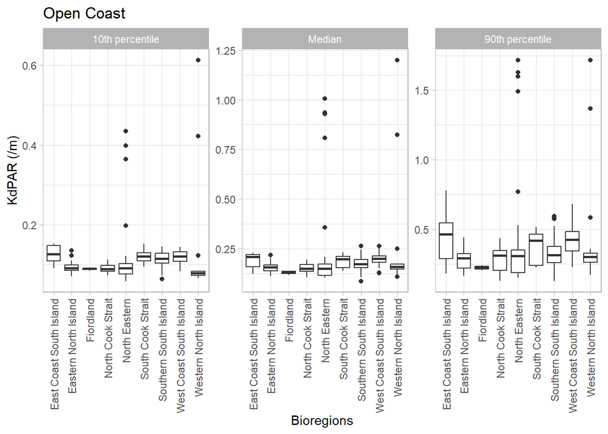

```r
p <- kd_metrics %>%
  mutate(Buffer_Size = Buffer_Size/1000) %>%
  filter(Buffer_Size == 10 & !is.na(KdPAR) & CLASS2 == "Open Coast" & Metrics %in% c('percentile10','median','percentile90')) %>%
  mutate(Metrics = case_when(Metrics == 'percentile10' ~  '10th percentile',
                             Metrics == 'median' ~  'Median',
                             Metrics == 'percentile90' ~  '90th percentile')) %>%
    mutate(Metrics = factor(Metrics,levels = c('percentile5','10th percentile','Median','90th percentile','percentile95'))) %>%
  ggplot(data=.,aes(x=factor(BioR__BioR),y=KdPAR)) +
  geom_boxplot() +
  facet_wrap(~Metrics,ncol=3,scales = 'free') +
  scale_fill_viridis_d() +
  ylab('KdPAR (/m)') + xlab('Bioregions') +
  ggtitle("Open Coast") +
  theme_light() +
  theme(legend.position = 'bottom',
        axis.text.x = element_text(angle = 90, vjust = 0.5, hjust=1))
p
```

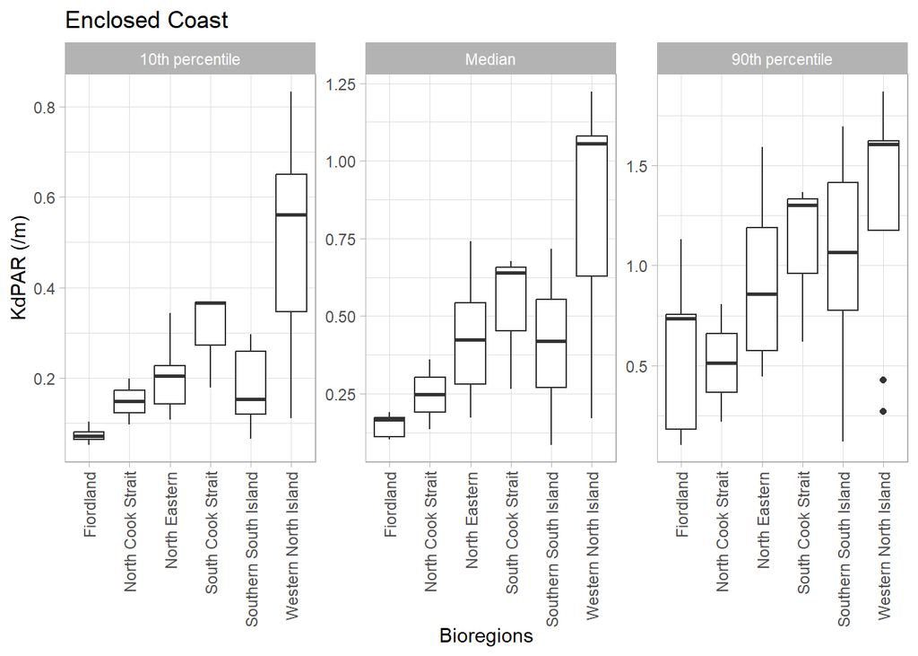

```r
p2 <- kd_metrics %>%
  mutate(Buffer_Size = Buffer_Size/1000) %>%
  filter(Buffer_Size == 10 & !is.na(KdPAR) & CLASS2 == "Enclosed Coast" & Metrics %in% c('percentile10','median','percentile90')) %>%
  mutate(Metrics = case_when(Metrics == 'percentile10' ~  '10th percentile',
                             Metrics == 'median' ~  'Median',
                             Metrics == 'percentile90' ~  '90th percentile')) %>%
    mutate(Metrics = factor(Metrics,levels = c('percentile5','10th percentile','Median','90th percentile','percentile95'))) %>%
  ggplot(data=.,aes(x=factor(BioR__BioR),y=KdPAR)) +
  geom_boxplot() +
  facet_wrap(~Metrics,ncol=3,scales = 'free') +
  scale_fill_viridis_d() +
  ylab('KdPAR (/m)') + xlab('Bioregions') +
  ggtitle("Enclosed Coast") +
  theme_light() +
  theme(legend.position = 'bottom',
        axis.text.x = element_text(angle = 90, vjust = 0.5, hjust=1))
p2
```

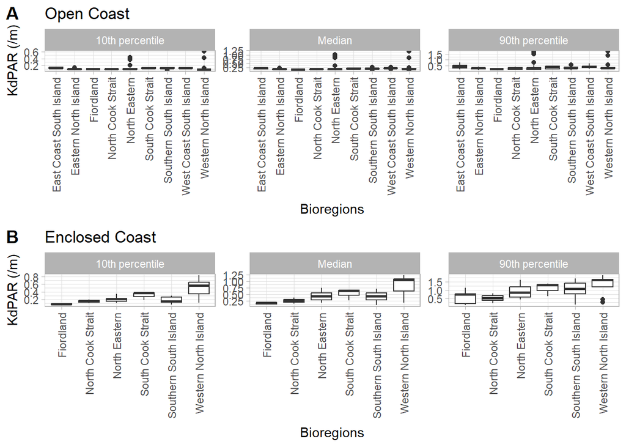

```r
figure9 <- ggarrange(p,
                     p2,
                     labels = c("A", "B"),
                     ncol = 1, nrow = 2)
figure9
```

##### 2.7.0.2 Percentile 5

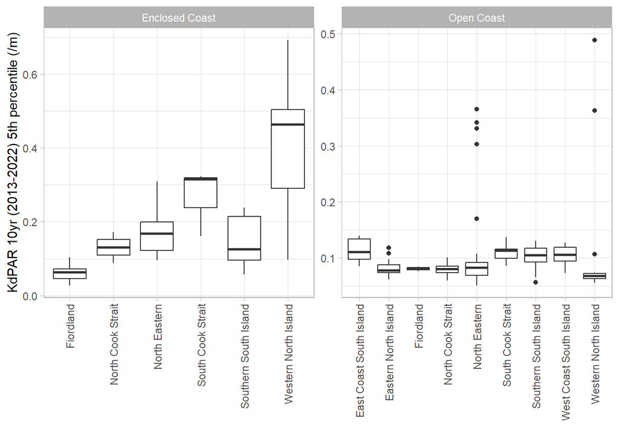

```r
p <- kd_metrics %>%
  mutate(Buffer_Size = Buffer_Size/1000) %>%
  filter(Buffer_Size == 10 & !is.na(KdPAR) & Metrics == 'percentile5') %>%
  ggplot(data=.,aes(x=factor(BioR__BioR),y=KdPAR)) +
  geom_boxplot() +
  facet_wrap(~CLASS2,scales='free',ncol=2) +
  scale_fill_viridis_d() +
  ylab('KdPAR 10yr (2013-2022) 5th percentile (/m)') + xlab('') +
  theme_light() +
  theme(legend.position = 'bottom',
        axis.text.x = element_text(angle = 90, vjust = 0.5, hjust=1))
p
```

###### 2.7.0.2.1 Open Coast

```r
aa <- kd_metrics %>%
  filter(Buffer_Size == 10000 &
         Metrics == 'percentile5' &
         CLASS2 == 'Open Coast') %>%
  #mutate(CLASS2_BioR = paste0(CLASS2,"_",BioR__BioR)) %>%
  select(KdPAR,BioR__BioR)

#pw <- pairwise.wilcox.test(aa$KdPAR,aa$CLASS2_BioR)
pw <- pairwise.wilcox.test(aa$KdPAR,aa$BioR__BioR)

pw %>%
  tidy() %>%
  pivot_wider(names_from = c(group2),values_from = p.value) %>%
  DT::datatable() %>%
  DT::formatStyle(columns = c(1:16),target = 'cell',fontWeight = styleInterval(.05, c('bold', 'normal'))) %>%
  #formatRound(c(2), 5) %>%
  formatStyle(columns = c(1:16), 'text-align' = 'center')
```

|  | group1 | East Coast South Island | Eastern North Island | Fiordland | North Cook Strait | North Eastern | South Cook Strait | Southern South Island | West Coast South Island |
| --- | --- | --- | --- | --- | --- | --- | --- | --- | --- |
| 1 | Eastern North Island | 1.171693922092916e-05 |  |  |  |  |  |  |  |
| 2 | Fiordland | 0.02371541501976284 | 1 |  |  |  |  |  |  |
| 3 | North Cook Strait | 3.595398008881109e-10 | 1 | 1 |  |  |  |  |  |
| 4 | North Eastern | 0.00407904587867236 | 1 | 1 | 1 |  |  |  |  |
| 5 | South Cook Strait | 1 | 0.005122313967891179 | 0.1328671328671329 | 2.626425518045722e-05 | 0.1294205518713658 |  |  |  |
| 6 | Southern South Island | 1 | 0.001667936848037684 | 0.1812807881773399 | 1.328819164130983e-05 | 0.04960171974734805 | 1 |  |  |
| 7 | West Coast South Island | 1 | 0.0001501065172251546 | 0.1794079794079794 | 1.133284392649428e-08 | 0.008467060144143975 | 1 | 1 |  |
| 8 | Western North Island | 0.008197385129730393 | 0.4902425507305127 | 1 | 0.1569678158116845 | 1 | 0.06086485115380305 | 0.03120724438698922 | 0.003609109984827125 |

###### 2.7.0.2.2 Enclosed Coast

```r
aa <- kd_metrics %>%
  filter(Buffer_Size == 10000 &
         Metrics == 'percentile5' &
         CLASS2 == 'Enclosed Coast') %>%
  select(KdPAR,BioR__BioR)

pw <- pairwise.wilcox.test(aa$KdPAR,aa$BioR__BioR)

pw %>%
  tidy() %>%
  pivot_wider(names_from = c(group2),values_from = p.value) %>%
  DT::datatable() %>%
  DT::formatStyle(columns = c(1:16),target = 'cell',fontWeight = styleInterval(.05, c('bold', 'normal'))) %>%
  #formatRound(c(2), 5) %>%
  formatStyle(columns = c(1:16), 'text-align' = 'center')
```

|  | group1 | Fiordland | North Cook Strait | North Eastern | South Cook Strait | Southern South Island |
| --- | --- | --- | --- | --- | --- | --- |
| 1 | North Cook Strait | 1 |  |  |  |  |
| 2 | North Eastern | 0.02997002997002997 | 1 |  |  |  |
| 3 | South Cook Strait | 0.4285714285714285 | 1 | 1 |  |  |
| 4 | Southern South Island | 0.5194805194805195 | 1 | 1 | 0.8571428571428571 |  |
| 5 | Western North Island | 0.07086351644445246 | 0.9971734484588188 | 0.4636920109762143 | 1 | 0.2787151795332187 |

##### 2.7.0.3 Percentile 10

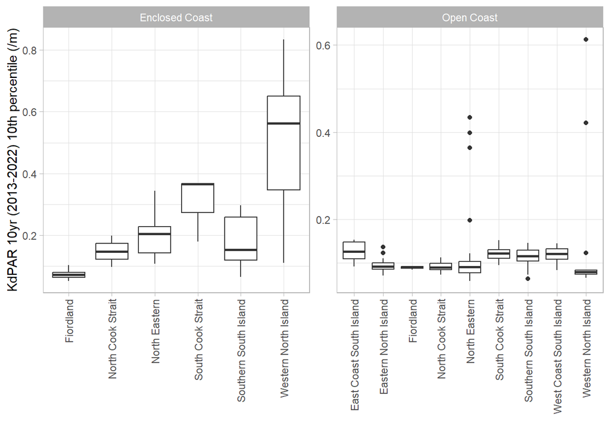

```r
p <- kd_metrics %>%
  mutate(Buffer_Size = Buffer_Size/1000) %>%
  filter(Buffer_Size == 10 & !is.na(KdPAR) & Metrics == 'percentile10') %>%
  ggplot(data=.,aes(x=factor(BioR__BioR),y=KdPAR)) +
  geom_boxplot() +
  facet_wrap(~CLASS2,scales='free',ncol=2) +
  scale_fill_viridis_d() +
  ylab('KdPAR 10yr (2013-2022) 10th percentile (/m)') + xlab('') +
  theme_light() +
  theme(legend.position = 'bottom',
        axis.text.x = element_text(angle = 90, vjust = 0.5, hjust=1))
p
```

###### 2.7.0.3.1 Open Coast

```r
aa <- kd_metrics %>%
  filter(Buffer_Size == 10000 &
         Metrics == 'percentile10' &
         CLASS2 == 'Open Coast') %>%
  select(KdPAR,BioR__BioR)

pw <- pairwise.wilcox.test(aa$KdPAR,aa$BioR__BioR)

pw %>%
  tidy() %>%
  pivot_wider(names_from = c(group2),values_from = p.value) %>%
  DT::datatable() %>%
  DT::formatStyle(columns = c(1:16),target = 'cell',fontWeight = styleInterval(.05, c('bold', 'normal'))) %>%
  formatStyle(columns = c(1:16), 'text-align' = 'center')
```

|  | group1 | East Coast South Island | Eastern North Island | Fiordland | North Cook Strait | North Eastern | South Cook Strait | Southern South Island | West Coast South Island |
| --- | --- | --- | --- | --- | --- | --- | --- | --- | --- |
| 1 | Eastern North Island | 0.0004148269701310329 |  |  |  |  |  |  |  |
| 2 | Fiordland | 0.04545454545454545 | 1 |  |  |  |  |  |  |
| 3 | North Cook Strait | 1.711409452227408e-08 | 1 | 1 |  |  |  |  |  |
| 4 | North Eastern | 0.006167665782549818 | 1 | 1 | 1 |  |  |  |  |
| 5 | South Cook Strait | 1 | 0.02195148568954199 | 0.1398601398601399 | 0.0002062090949984964 | 0.1899613899613899 |  |  |  |
| 6 | Southern South Island | 0.7746921114054061 | 0.00595563861271866 | 0.1899613899613899 | 9.731987086112592e-05 | 0.0625781015424995 | 1 |  |  |
| 7 | West Coast South Island | 1 | 0.0006432619584884251 | 0.1899613899613899 | 2.217901010384387e-08 | 0.005761107453946996 | 1 | 1 |  |
| 8 | Western North Island | 0.008197385129730393 | 0.5320000823283295 | 1 | 0.1486811101596969 | 1 | 0.100793200883279 | 0.04041199988817933 | 0.004062576434273268 |

###### 2.7.0.3.2 Enclosed Coast

```r
aa <- kd_metrics %>%
  filter(Buffer_Size == 10000 &
         Metrics == 'percentile10' &
         CLASS2 == 'Enclosed Coast') %>%
  select(KdPAR,BioR__BioR)

pw <- pairwise.wilcox.test(aa$KdPAR,aa$BioR__BioR)

pw %>%
  tidy() %>%
  pivot_wider(names_from = c(group2),values_from = p.value) %>%
  DT::datatable() %>%
  DT::formatStyle(columns = c(1:16),target = 'cell',fontWeight = styleInterval(.05, c('bold', 'normal'))) %>%
  formatStyle(columns = c(1:16), 'text-align' = 'center')
```

|  | group1 | Fiordland | North Cook Strait | North Eastern | South Cook Strait | Southern South Island |
| --- | --- | --- | --- | --- | --- | --- |
| 1 | North Cook Strait | 1 |  |  |  |  |
| 2 | North Eastern | 0.01498501498501498 | 1 |  |  |  |
| 3 | South Cook Strait | 0.4077223793920395 | 1 | 1 |  |  |
| 4 | Southern South Island | 0.3939393939393939 | 1 | 1 | 0.8571428571428571 |  |
| 5 | Western North Island | 0.04646213125868097 | 0.9971734484588188 | 0.4077223793920395 | 1 | 0.4077223793920395 |

##### 2.7.0.4 Mean

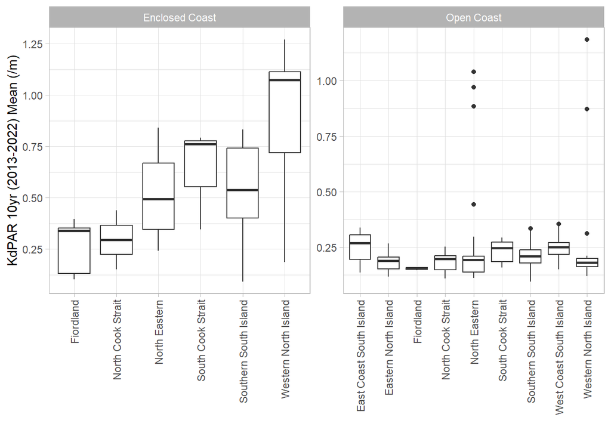

```r
p <- kd_metrics %>%
  mutate(Buffer_Size = Buffer_Size/1000) %>%
  filter(Buffer_Size == 10 & !is.na(KdPAR) & Metrics == 'mean') %>%
  ggplot(data=.,aes(x=factor(BioR__BioR),y=KdPAR)) +
  geom_boxplot() +
  facet_wrap(~CLASS2,scales='free',ncol=2) +
  scale_fill_viridis_d() +
  ylab('KdPAR 10yr (2013-2022) Mean (/m)') + xlab('') +
  theme_light() +
  theme(legend.position = 'bottom',
        axis.text.x = element_text(angle = 90, vjust = 0.5, hjust=1))
p
```

###### 2.7.0.4.1 Open Coast

```r
aa <- kd_metrics %>%
  filter(Buffer_Size == 10000 &
         Metrics == 'mean' &
         CLASS2 == 'Open Coast') %>%
  select(KdPAR,BioR__BioR)

pw <- pairwise.wilcox.test(aa$KdPAR,aa$BioR__BioR)

pw %>%
  tidy() %>%
  pivot_wider(names_from = c(group2),values_from = p.value) %>%
  DT::datatable() %>%
  DT::formatStyle(columns = c(1:16),target = 'cell',fontWeight = styleInterval(.05, c('bold', 'normal'))) %>%
  formatStyle(columns = c(1:16), 'text-align' = 'center')
```

|  | group1 | East Coast South Island | Eastern North Island | Fiordland | North Cook Strait | North Eastern | South Cook Strait | Southern South Island | West Coast South Island |
| --- | --- | --- | --- | --- | --- | --- | --- | --- | --- |
| 1 | Eastern North Island | 0.07709874223575908 |  |  |  |  |  |  |  |
| 2 | Fiordland | 0.3152173913043478 | 1 |  |  |  |  |  |  |
| 3 | North Cook Strait | 0.03918460574798667 | 1 | 1 |  |  |  |  |  |
| 4 | North Eastern | 0.5839379700794337 | 1 | 1 | 1 |  |  |  |  |
| 5 | South Cook Strait | 1 | 0.9113599044633528 | 0.7272727272727273 | 0.7718525393392893 | 1 |  |  |  |
| 6 | Southern South Island | 1 | 1 | 0.7921182266009852 | 1 | 1 | 1 |  |  |
| 7 | West Coast South Island | 1 | 0.0004488987552720436 | 0.08494208494208494 | 1.665225908029236e-05 | 0.02394125932976491 | 1 | 0.3823578408203506 |  |
| 8 | Western North Island | 1 | 1 | 1 | 1 | 1 | 1 | 1 | 0.07709874223575908 |

###### 2.7.0.4.2 Enclosed Coast

```r
aa <- kd_metrics %>%
  filter(Buffer_Size == 10000 &
         Metrics == 'mean' &
         CLASS2 == 'Enclosed Coast') %>%
  select(KdPAR,BioR__BioR)

pw <- pairwise.wilcox.test(aa$KdPAR,aa$BioR__BioR)

pw %>%
  tidy() %>%
  pivot_wider(names_from = c(group2),values_from = p.value) %>%
  DT::datatable() %>%
  DT::formatStyle(columns = c(1:16),target = 'cell',fontWeight = styleInterval(.05, c('bold', 'normal'))) %>%
  formatStyle(columns = c(1:16), 'text-align' = 'center')
```

|  | group1 | Fiordland | North Cook Strait | North Eastern | South Cook Strait | Southern South Island |
| --- | --- | --- | --- | --- | --- | --- |
| 1 | North Cook Strait | 1 |  |  |  |  |
| 2 | North Eastern | 0.8391608391608392 | 1 |  |  |  |
| 3 | South Cook Strait | 1 | 1 | 1 |  |  |
| 4 | Southern South Island | 1 | 1 | 1 | 1 |  |
| 5 | Western North Island | 0.4905807169054646 | 1 | 0.8391608391608392 | 1 | 1 |

##### 2.7.0.5 Median

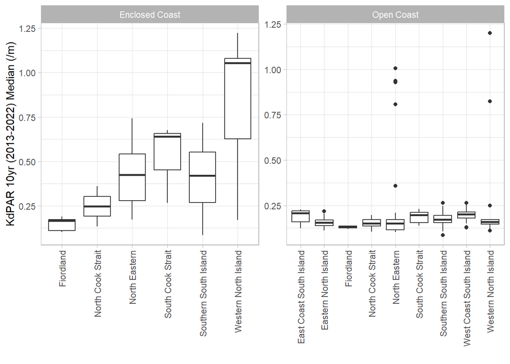

```r
p <- kd_metrics %>%
  mutate(Buffer_Size = Buffer_Size/1000) %>%
  filter(Buffer_Size == 10 & !is.na(KdPAR) & Metrics == 'median') %>%
  ggplot(data=.,aes(x=factor(BioR__BioR),y=KdPAR)) +
  geom_boxplot() +
  facet_wrap(~CLASS2,scales='free',ncol=2) +
  scale_fill_viridis_d() +
  ylab('KdPAR 10yr (2013-2022) Median (/m)') + xlab('') +
  theme_light() +
  theme(legend.position = 'bottom',
        axis.text.x = element_text(angle = 90, vjust = 0.5, hjust=1))
p
```

###### 2.7.0.5.1 Open Coast

```r
aa <- kd_metrics %>%
  filter(Buffer_Size == 10000 &
         Metrics == 'median' &
         CLASS2 == 'Open Coast') %>%
  select(KdPAR,BioR__BioR)

pw <- pairwise.wilcox.test(aa$KdPAR,aa$BioR__BioR)

pw %>%
  tidy() %>%
  pivot_wider(names_from = c(group2),values_from = p.value) %>%
  DT::datatable() %>%
  DT::formatStyle(columns = c(1:16),target = 'cell',fontWeight = styleInterval(.05, c('bold', 'normal'))) %>%
  formatStyle(columns = c(1:16), 'text-align' = 'center')
```

|  | group1 | East Coast South Island | Eastern North Island | Fiordland | North Cook Strait | North Eastern | South Cook Strait | Southern South Island | West Coast South Island |
| --- | --- | --- | --- | --- | --- | --- | --- | --- | --- |
| 1 | Eastern North Island | 0.1126220008294412 |  |  |  |  |  |  |  |
| 2 | Fiordland | 0.1146245059288537 | 1 |  |  |  |  |  |  |
| 3 | North Cook Strait | 0.006777425487769008 | 1 | 1 |  |  |  |  |  |
| 4 | North Eastern | 0.3525469966663231 | 1 | 1 | 1 |  |  |  |  |
| 5 | South Cook Strait | 1 | 1 | 0.3636363636363636 | 0.3997542963697308 | 1 |  |  |  |
| 6 | Southern South Island | 1 | 0.8826533386486342 | 0.4645320197044335 | 0.2936244052686432 | 1 | 1 |  |  |
| 7 | West Coast South Island | 1 | 0.001843506920767925 | 0.0906048906048906 | 1.025057331725138e-06 | 0.009946251170478485 | 1 | 0.4204133955836544 |  |
| 8 | Western North Island | 1 | 1 | 0.9969040247678017 | 1 | 1 | 1 | 1 | 0.1084236772414344 |

###### 2.7.0.5.2 Enclosed Coast

```r
aa <- kd_metrics %>%
  filter(Buffer_Size == 10000 &
         Metrics == 'median' &
         CLASS2 == 'Enclosed Coast') %>%
  select(KdPAR,BioR__BioR)

pw <- pairwise.wilcox.test(aa$KdPAR,aa$BioR__BioR)

pw %>%
  tidy() %>%
  pivot_wider(names_from = c(group2),values_from = p.value) %>%
  DT::datatable() %>%
  DT::formatStyle(columns = c(1:16),target = 'cell',fontWeight = styleInterval(.05, c('bold', 'normal'))) %>%
  formatStyle(columns = c(1:16), 'text-align' = 'center')
```

|  | group1 | Fiordland | North Cook Strait | North Eastern | South Cook Strait | Southern South Island |
| --- | --- | --- | --- | --- | --- | --- |
| 1 | North Cook Strait | 1 |  |  |  |  |
| 2 | North Eastern | 0.05994005994005994 | 1 |  |  |  |
| 3 | South Cook Strait | 0.4642857142857142 | 1 | 1 |  |  |
| 4 | Southern South Island | 0.9047619047619048 | 1 | 1 | 1 |  |
| 5 | Western North Island | 0.1063177138207638 | 1 | 0.762635853712803 | 1 | 0.9047619047619048 |

##### 2.7.0.6 Percentile 90

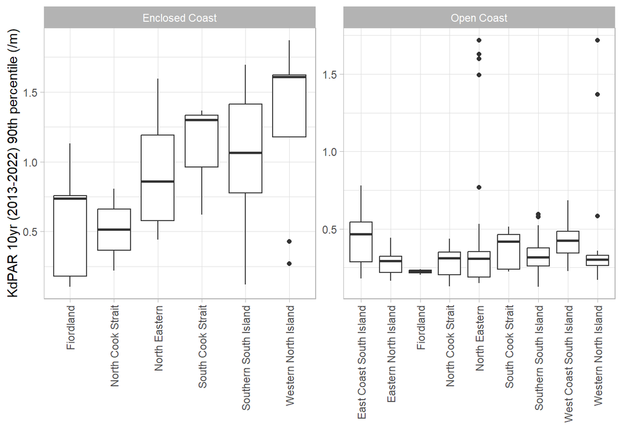

```r
p <- kd_metrics %>%
  mutate(Buffer_Size = Buffer_Size/1000) %>%
  filter(Buffer_Size == 10 & !is.na(KdPAR) & Metrics == 'percentile90') %>%
  ggplot(data=.,aes(x=factor(BioR__BioR),y=KdPAR)) +
  geom_boxplot() +
  facet_wrap(~CLASS2,scales='free',ncol=2) +
  scale_fill_viridis_d() +
  ylab('KdPAR 10yr (2013-2022) 90th percentile (/m)') + xlab('') +
  theme_light() +
  theme(legend.position = 'bottom',
        axis.text.x = element_text(angle = 90, vjust = 0.5, hjust=1))
p
```

###### 2.7.0.6.1 Open Coast

```r
aa <- kd_metrics %>%
  filter(Buffer_Size == 10000 &
         Metrics == 'percentile90' &
         CLASS2 == 'Open Coast') %>%
  select(KdPAR,BioR__BioR)

pw <- pairwise.wilcox.test(aa$KdPAR,aa$BioR__BioR)

pw %>%
  tidy() %>%
  pivot_wider(names_from = c(group2),values_from = p.value) %>%
  DT::datatable() %>%
  DT::formatStyle(columns = c(1:16),target = 'cell',fontWeight = styleInterval(.05, c('bold', 'normal'))) %>%
  formatStyle(columns = c(1:16), 'text-align' = 'center')
```

|  | group1 | East Coast South Island | Eastern North Island | Fiordland | North Cook Strait | North Eastern | South Cook Strait | Southern South Island | West Coast South Island |
| --- | --- | --- | --- | --- | --- | --- | --- | --- | --- |
| 1 | Eastern North Island | 0.1324076614060654 |  |  |  |  |  |  |  |
| 2 | Fiordland | 0.857707509881423 | 1 |  |  |  |  |  |  |
| 3 | North Cook Strait | 0.07510942790337749 | 1 | 1 |  |  |  |  |  |
| 4 | North Eastern | 1 | 1 | 1 | 1 |  |  |  |  |
| 5 | South Cook Strait | 1 | 1 | 1 | 1 | 1 |  |  |  |
| 6 | Southern South Island | 1 | 1 | 1 | 1 | 1 | 1 |  |  |
| 7 | West Coast South Island | 1 | 0.0001514399617674245 | 0.035006435006435 | 8.835296474092426e-05 | 0.05389061234734249 | 1 | 0.07518757002938857 |  |
| 8 | Western North Island | 1 | 1 | 1 | 1 | 1 | 1 | 1 | 0.1555040476015589 |

###### 2.7.0.6.2 Enclosed Coast

```r
aa <- kd_metrics %>%
  filter(Buffer_Size == 10000 &
         Metrics == 'percentile90' &
         CLASS2 == 'Enclosed Coast') %>%
  select(KdPAR,BioR__BioR)

pw <- pairwise.wilcox.test(aa$KdPAR,aa$BioR__BioR)

pw %>%
  tidy() %>%
  pivot_wider(names_from = c(group2),values_from = p.value) %>%
  DT::datatable() %>%
  DT::formatStyle(columns = c(1:16),target = 'cell',fontWeight = styleInterval(.05, c('bold', 'normal'))) %>%
  formatStyle(columns = c(1:16), 'text-align' = 'center')
```

|  | group1 | Fiordland | North Cook Strait | North Eastern | South Cook Strait | Southern South Island |
| --- | --- | --- | --- | --- | --- | --- |
| 1 | North Cook Strait | 1 |  |  |  |  |
| 2 | North Eastern | 1 | 1 |  |  |  |
| 3 | South Cook Strait | 1 | 1 | 1 |  |  |
| 4 | Southern South Island | 1 | 1 | 1 | 1 |  |
| 5 | Western North Island | 0.4905807169054646 | 1 | 1 | 1 | 1 |

##### 2.7.0.7 Percentile 95

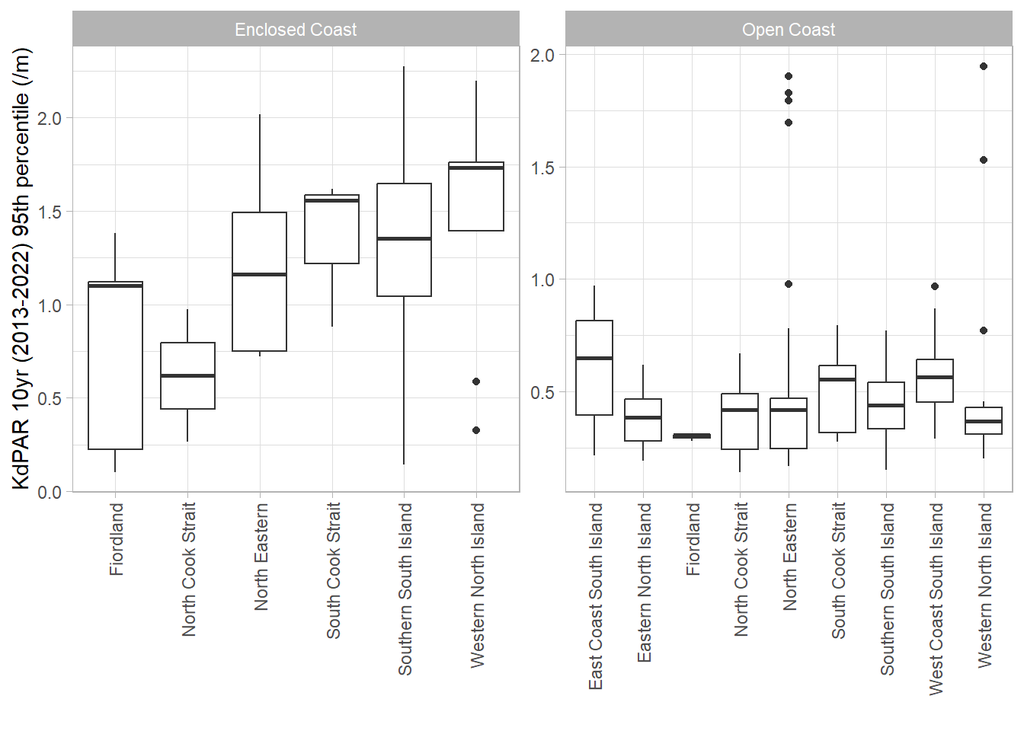

```r
p <- kd_metrics %>%
  mutate(Buffer_Size = Buffer_Size/1000) %>%
  filter(Buffer_Size == 10 & !is.na(KdPAR) & Metrics == 'percentile95') %>%
  ggplot(data=.,aes(x=factor(BioR__BioR),y=KdPAR)) +
  geom_boxplot() +
  facet_wrap(~CLASS2,scales='free',ncol=2) +
  scale_fill_viridis_d() +
  ylab('KdPAR 10yr (2013-2022) 95th percentile (/m)') + xlab('') +
  theme_light() +
  theme(legend.position = 'bottom',
        axis.text.x = element_text(angle = 90, vjust = 0.5, hjust=1))
p
```

###### 2.7.0.7.1 Open Coast

```r
aa <- kd_metrics %>%
  filter(Buffer_Size == 10000 &
         Metrics == 'percentile95' &
         CLASS2 == 'Open Coast') %>%
  select(KdPAR,BioR__BioR)

pw <- pairwise.wilcox.test(aa$KdPAR,aa$BioR__BioR)

pw %>%
  tidy() %>%
  pivot_wider(names_from = c(group2),values_from = p.value) %>%
  DT::datatable() %>%
  DT::formatStyle(columns = c(1:16),target = 'cell',fontWeight = styleInterval(.05, c('bold', 'normal'))) %>%
  formatStyle(columns = c(1:16), 'text-align' = 'center')
```

|  | group1 | East Coast South Island | Eastern North Island | Fiordland | North Cook Strait | North Eastern | South Cook Strait | Southern South Island | West Coast South Island |
| --- | --- | --- | --- | --- | --- | --- | --- | --- | --- |
| 1 | Eastern North Island | 0.1452365261452653 |  |  |  |  |  |  |  |
| 2 | Fiordland | 1 | 1 |  |  |  |  |  |  |
| 3 | North Cook Strait | 0.09626769626769627 | 1 | 1 |  |  |  |  |  |
| 4 | North Eastern | 1 | 1 | 1 | 1 |  |  |  |  |
| 5 | South Cook Strait | 1 | 1 | 1 | 1 | 1 |  |  |  |
| 6 | Southern South Island | 0.9782094452264222 | 1 | 1 | 1 | 1 | 1 |  |  |
| 7 | West Coast South Island | 1 | 0.004209844020245649 | 0.09626769626769627 | 0.004539865851865441 | 0.1309104557973379 | 1 | 0.1623336251723484 |  |
| 8 | Western North Island | 1 | 1 | 1 | 1 | 1 | 1 | 1 | 0.1445008710304015 |

###### 2.7.0.7.2 Enclosed Coast

```r
aa <- kd_metrics %>%
  filter(Buffer_Size == 10000 &
         Metrics == 'percentile95' &
         CLASS2 == 'Enclosed Coast') %>%
  select(KdPAR,BioR__BioR)

pw <- pairwise.wilcox.test(aa$KdPAR,aa$BioR__BioR)

pw %>%
  tidy() %>%
  pivot_wider(names_from = c(group2),values_from = p.value) %>%
  DT::datatable() %>%
  DT::formatStyle(columns = c(1:16),target = 'cell',fontWeight = styleInterval(.05, c('bold', 'normal'))) %>%
  formatStyle(columns = c(1:16), 'text-align' = 'center')
```

|  | group1 | Fiordland | North Cook Strait | North Eastern | South Cook Strait | Southern South Island |
| --- | --- | --- | --- | --- | --- | --- |
| 1 | North Cook Strait | 1 |  |  |  |  |
| 2 | North Eastern | 1 | 1 |  |  |  |
| 3 | South Cook Strait | 1 | 1 | 1 |  |  |
| 4 | Southern South Island | 1 | 1 | 1 | 1 |  |
| 5 | Western North Island | 0.4905807169054646 | 1 | 1 | 1 | 1 |

### 2.8 Figure 10 Time series of National and river with highest KdPAR

#### 2.8.1 Time series national scale

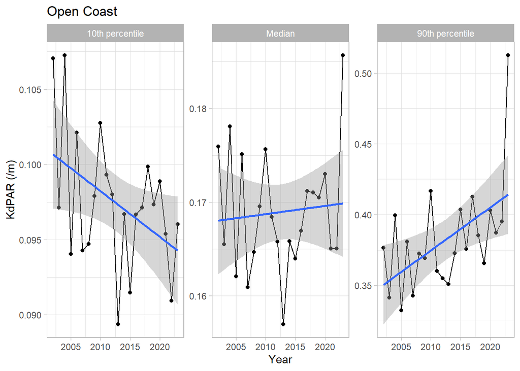

```r
kd_ts_10km <- read_csv('KdPAR_SCENZ_1D_v05_Buffer_10000m_RiverMouths_REC2.csv')

kd_ts_10km <- inner_join(kd_ts_10km,rivermouth %>% select(RID,NAME_name2,CLASS2))

kd_ts_10km_yearly_sum <- kd_ts_10km %>%
  mutate(year = year(Date)) %>%
  group_by(year,CLASS2) %>%
  summarise(KdPAR_median = median(KdPAR,na.rm=T),
            KdPAR_10p = quantile(KdPAR,na.rm=T,0.1),
            KdPAR_90p = quantile(KdPAR,na.rm=T,0.9))

p <- kd_ts_10km_yearly_sum %>%
  filter(CLASS2 == 'Open Coast') %>%
  pivot_longer(-c(year,CLASS2)) %>%
  mutate(name = case_when(name == 'KdPAR_10p' ~  '10th percentile',
                             name == 'KdPAR_median' ~  'Median',
                             name == 'KdPAR_90p' ~  '90th percentile')) %>%
  mutate(name = factor(name,levels = c('10th percentile','Median','90th percentile'))) %>%
  ggplot(data=.,aes(x=year,y=value)) +
  geom_point() +
  geom_line() +
  ylab('KdPAR (/m)') + xlab('Year') +
  geom_smooth(method = 'lm') +
  ggtitle("Open Coast") +
  facet_wrap(~name,nrow=1,scales = 'free') +
  theme_light()
p
```

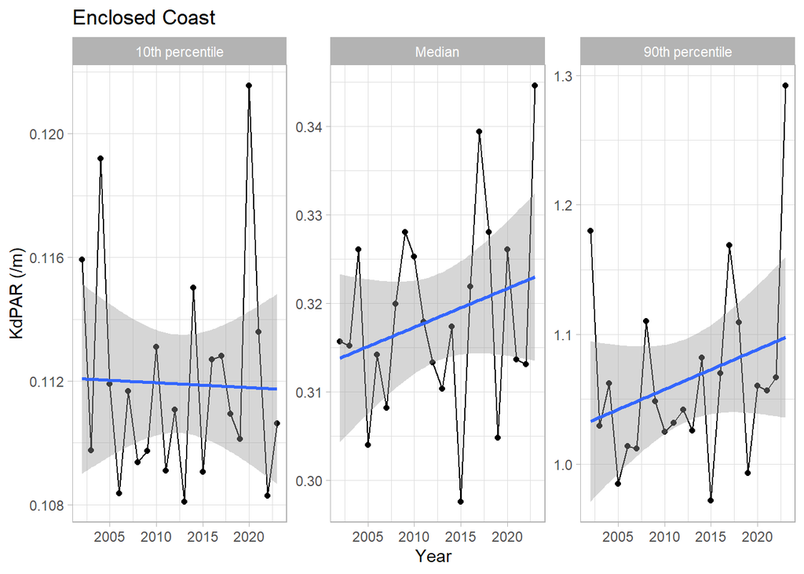

```r
p2 <- kd_ts_10km_yearly_sum %>%
  filter(CLASS2 == 'Enclosed Coast') %>%
  pivot_longer(-c(year,CLASS2)) %>%
  mutate(name = case_when(name == 'KdPAR_10p' ~  '10th percentile',
                             name == 'KdPAR_median' ~  'Median',
                             name == 'KdPAR_90p' ~  '90th percentile')) %>%
  mutate(name = factor(name,levels = c('10th percentile','Median','90th percentile'))) %>%
  ggplot(data=.,aes(x=year,y=value)) +
  geom_point() +
  geom_line() +
  ylab('KdPAR (/m)') + xlab('Year') +
  geom_smooth(method = 'lm') +
  ggtitle("Enclosed Coast") +
  facet_wrap(~name,nrow=1,scales = 'free') +
  theme_light()
p2
```

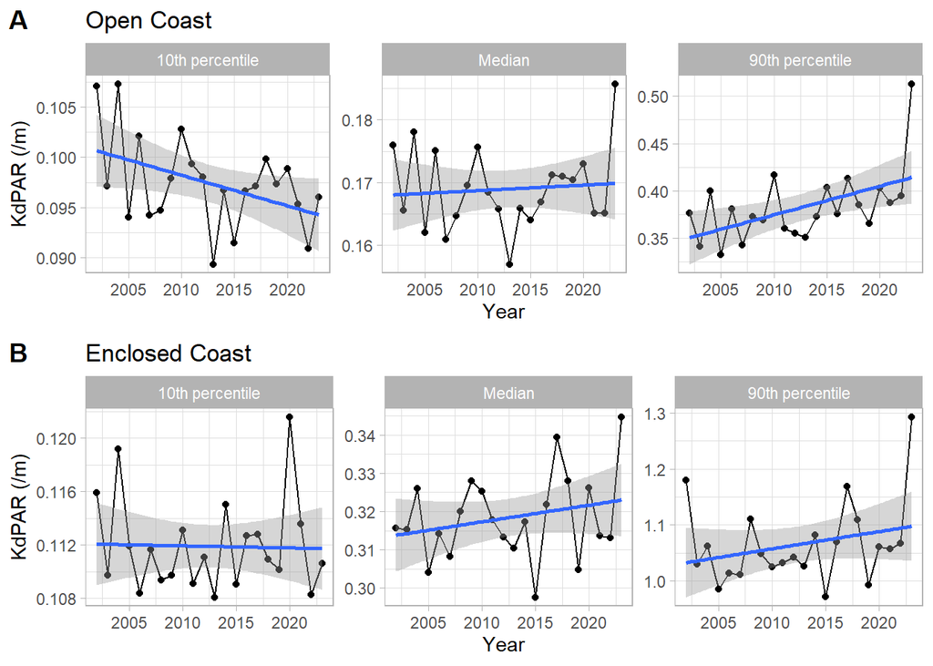

```r
figure10 <- ggarrange(p,
                     p2,
                     labels = c("A", "B"),
                     ncol = 1, nrow = 2)
figure10
```

##### 2.8.1.1 Trends

```r
trends <- kd_ts_10km_yearly_sum %>%
  pivot_longer(-c(year,CLASS2)) %>%
  group_by(CLASS2,name) %>%
  nest() %>%
    mutate(ts_out = purrr::map(data, ~ts(.x$value,start=2002,end=2023,frequency = 1))) %>%
  mutate(sens = purrr::map(ts_out, ~sens.slope(.x, conf.level = 0.95))) %>%
  mutate(Sens_Slope = as.numeric(unlist(sens)[1]),P_Value =as.numeric(unlist(sens)[3])) %>%
  select(CLASS2,name, Sens_Slope, P_Value)

trends %>%
  DT::datatable()
```

|  | CLASS2 | name | Sens_Slope | P_Value |
| --- | --- | --- | --- | --- |
| 1 | Enclosed Coast | KdPAR_median | 0.000332875177264214 | 0.535024450618287 |
| 2 | Enclosed Coast | KdPAR_10p | -4.02063131332425e-05 | 0.777959384381542 |
| 3 | Enclosed Coast | KdPAR_90p | 0.00290362076325849 | 0.236289164502374 |
| 4 | Open Coast | KdPAR_median | 2.91524025110098e-05 | 0.843464428525719 |
| 5 | Open Coast | KdPAR_10p | -0.000245304778218269 | 0.166895505784706 |
| 6 | Open Coast | KdPAR_90p | 0.00244947552680967 | 0.0240810051773448 |

#### 2.8.2 Rivermouths ranked by highest KdPAR values (mean 2002-2023 period)

```r
## Rankings of most dirty rivermouth
kd_ts_10km_summary <- kd_ts_10km %>%
  group_by(RID,NAME,name_2,CLASS2) %>%
  summarise(KdPAR_mean = round(mean(KdPAR,na.rm=T),3),
            KdPAR_sd = round(sd(KdPAR,na.rm=T),3)) %>%
  arrange(desc(KdPAR_mean))
#write_csv(kd_ts_10km_summary,'KdPAR_2002_2023_mean_sd_Rivermouth_ranked.csv')

kd_ts_10km_summary %>%
  DT::datatable()
```

|  | RID | NAME | name_2 | CLASS2 | KdPAR_mean | KdPAR_sd |
| --- | --- | --- | --- | --- | --- | --- |
| 1 | 12 | Kaipara Harbour System | Topuni River | Enclosed Coast | 1.282 | 0.47 |
| 2 | 15 | Lucas Creek (WHS) | Kaipara River | Enclosed Coast | 1.155 | 0.433 |
| 3 | 14 | Orewa River | Kaukapakapa River | Open Coast | 1.142 | 0.429 |
| 4 | 21 | Pahurehure Inlet (MHS) | Hingaia Stream | Enclosed Coast | 1.107 | 0.398 |
| 5 | 29 | Waitetuna Creek (RHS) | Waingaro River | Enclosed Coast | 1.095 | 0.373 |
| 6 | 33 | Waitetuna Creek (RHS) | Waitetuna River | Enclosed Coast | 1.095 | 0.373 |
| 7 | 143 | Waihou River | Waihou River (Waikato) | Open Coast | 1.07 | 0.509 |
| 8 | 23 | Kauranga River | Kauaeranga River | Open Coast | 1.004 | 0.491 |
| 9 | 144 | Piako River | Piako River | Open Coast | 1 | 0.481 |
| 10 | 24 | Waitakaruru River | Waitakaruru Canal | Open Coast | 0.914 | 0.487 |

[output cut: 211 more lines]

### 2.9 Figure 11 KdPAR mean for all rivers

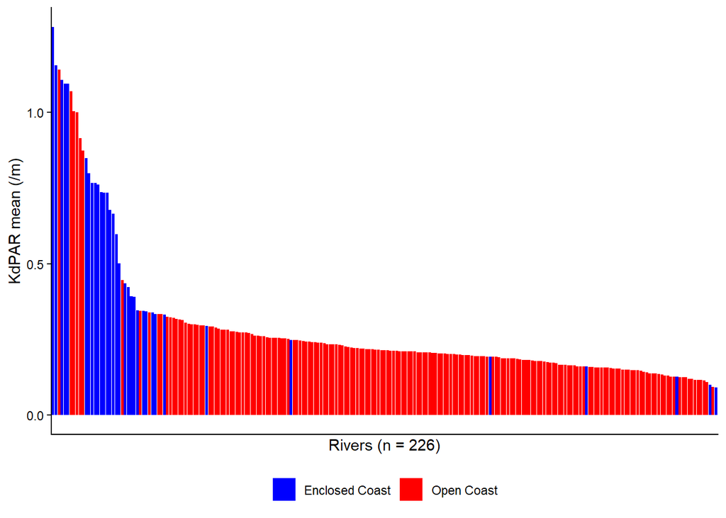

```r
kd_mean_10km <- kd_ts_10km %>% group_by(CLASS2,RID,NAME,name_2,NAME_name2) %>%
  summarise(KdPAR_mean = mean(KdPAR,na.rm=T)) %>%
  arrange(desc(KdPAR_mean))
p <- kd_mean_10km %>%
  arrange(desc(KdPAR_mean)) %>%
  ggplot(data=.,aes(x=fct_inorder(NAME_name2) ,y=KdPAR_mean,fill=CLASS2)) +#colour
  #geom_segment(aes(xend=NAME_name2 ,y = 0, yend=KdPAR_mean,colour=CLASS2),size=.5) +
  #scale_colour_manual(values=c('blue','red')) +
  #geom_point(size=2) +
  scale_fill_manual(values=c('blue','red')) +
  geom_col() +
  xlab('Rivers (n = 226)') + ylab('KdPAR mean (/m)') +
  theme_classic() +
  theme(legend.position = 'bottom',
        legend.title = element_blank(),
        axis.text.x=element_blank(),
        axis.ticks.x=element_blank())
p
```

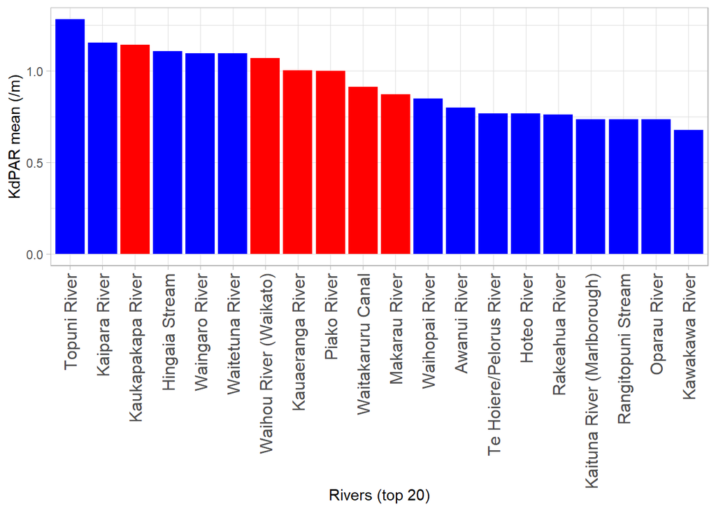

```r
p2 <- kd_mean_10km[1:20,] %>%# kd_mean_10km[1:20,]
  ggplot(data=.,aes(x=fct_inorder(name_2) ,y=KdPAR_mean,fill=CLASS2)) +#colour
  #geom_segment(aes(xend= ,y = 0, yend=KdPAR_mean,colour=CLASS2)) +
  #scale_colour_manual(values=c('blue','red')) +
  scale_fill_manual(values=c('blue','red')) +
  geom_col() +
  #geom_point(size=2) +
  xlab('Rivers (top 20)') + ylab('KdPAR mean (/m)') +
  theme_light() +
  theme(legend.position = 'none',
        axis.text.x = element_text(size = 12, angle = 90, vjust = 0.5, hjust=1))
p2
```

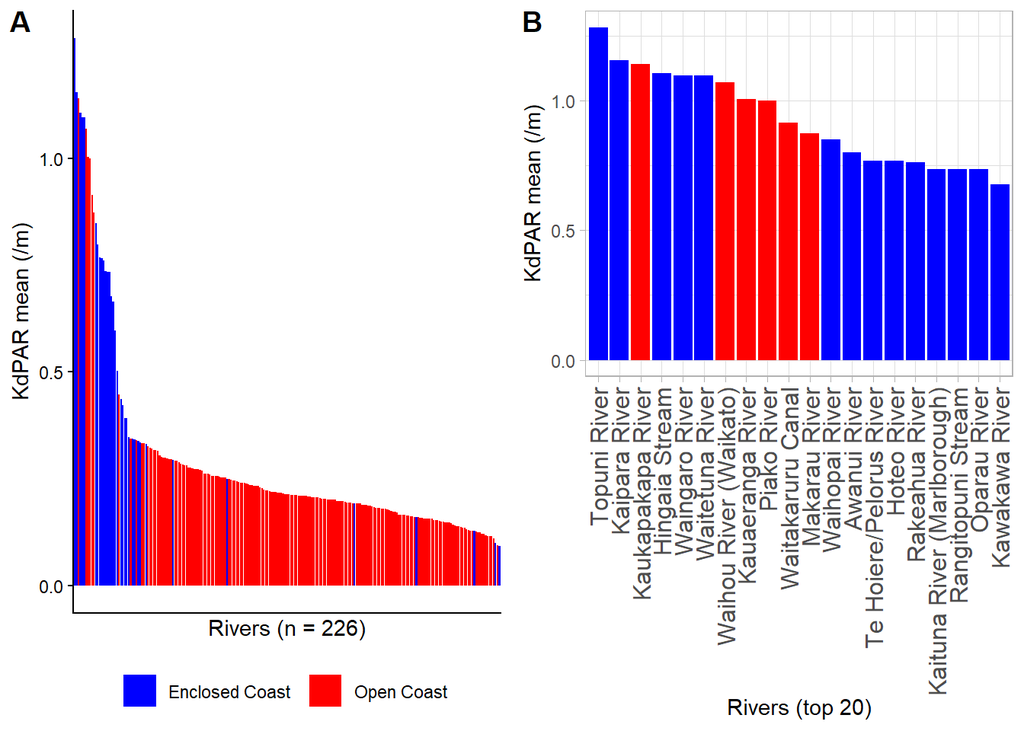

```r
figure11 <- ggarrange(p,
                     p2,
                     widths = c(5, 5),#3,2
                     labels = c("A", "B"),
                     ncol = 2, nrow = 1)
figure11
```

### 2.10 Supplementary Information

### 2.11 Fig S1

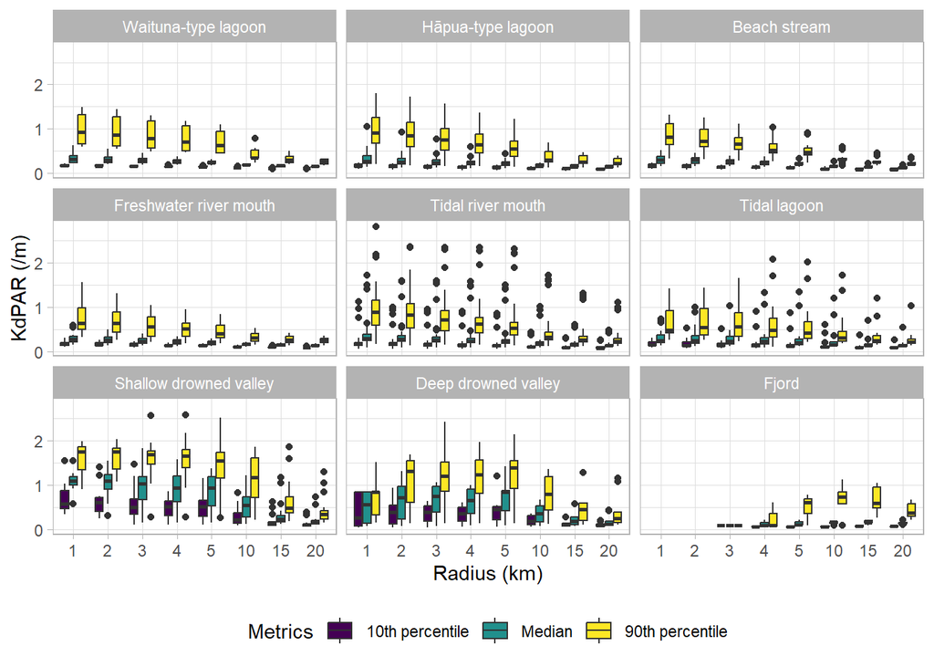

```r
figS1 <- kd_metrics %>%
  filter(Metrics %in% c('median','percentile10','percentile90')) %>%
  filter(!is.na(KdPAR)) %>%
  mutate(Buffer_Size = Buffer_Size/1000) %>%
  mutate(Metrics = case_when(Metrics == 'percentile10' ~  '10th percentile',
                             Metrics == 'median' ~  'Median',
                             Metrics == 'percentile90' ~  '90th percentile')) %>%
  mutate(Metrics = factor(Metrics,levels = c('10th percentile','Median','90th percentile'))) %>%
  ggplot(data=.,aes(x=factor(Buffer_Size),y=KdPAR,fill=Metrics)) +
  geom_boxplot() +
  scale_fill_viridis_d() +
  facet_wrap(~CLASS) +
  #ggtitle('Percentage of valid observations of KdPAR (2013-2022)') +
  ylab('KdPAR (/m)') + xlab('Radius (km)') +
  theme_light() +
  theme(legend.position = 'bottom')
figS1
```

### 2.12 Fig S2

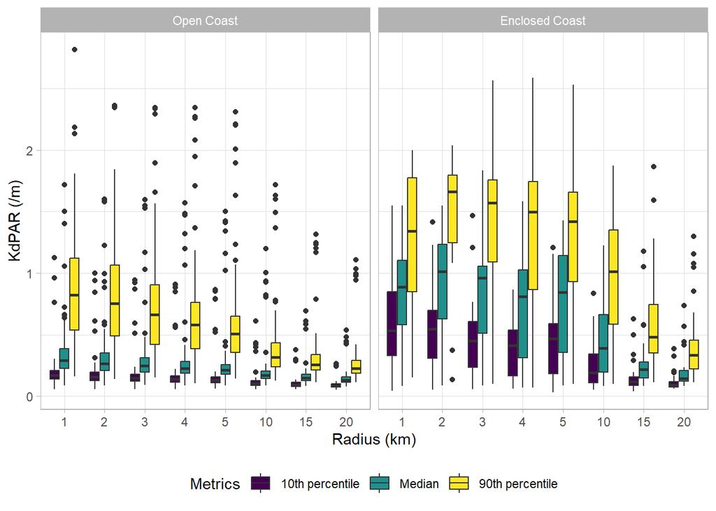

```r
figS2 <- kd_metrics %>%
  filter(Metrics %in% c('median','percentile10','percentile90')) %>%
  filter(!is.na(KdPAR)) %>%
  mutate(CLASS2 = factor(CLASS2,levels = c('Open Coast','Enclosed Coast'))) %>%
  mutate(Buffer_Size = Buffer_Size/1000) %>%
  mutate(Metrics = case_when(Metrics == 'percentile10' ~  '10th percentile',
                             Metrics == 'median' ~  'Median',
                             Metrics == 'percentile90' ~  '90th percentile')) %>%
  mutate(Metrics = factor(Metrics,levels = c('10th percentile','Median','90th percentile'))) %>%
  ggplot(data=.,aes(x=factor(Buffer_Size),y=KdPAR,fill=Metrics)) +
  geom_boxplot() +
  scale_fill_viridis_d() +
  facet_wrap(~CLASS2) +
  #ggtitle('Percentage of valid observations of KdPAR (2013-2022)') +
  ylab('KdPAR (/m)') + xlab('Radius (km)') +
  theme_light() +
  theme(legend.position = 'bottom')
figS2
```

### 2.13 Fig S3 KdPAR 90th percentile vs Catchment Size

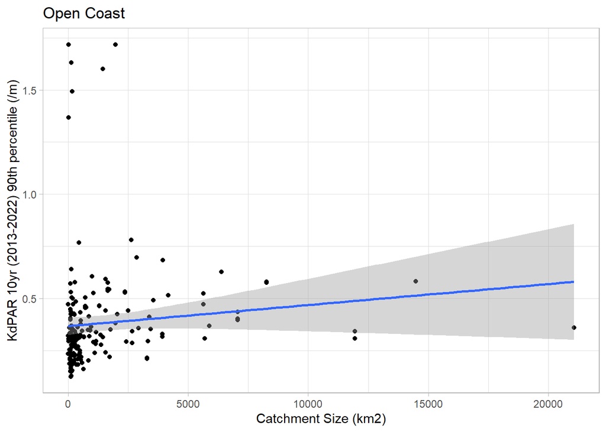

```r
p <- kd_metrics %>%
  mutate(Buffer_Size = Buffer_Size/1000) %>%
  filter(Buffer_Size == 10 & !is.na(KdPAR) & Metrics == 'percentile90' & CATCHMT_AR>0 & CLASS2 == 'Open Coast') %>%
  ggplot(data=.,aes(x=CATCHMT_AR,y=KdPAR)) +
  geom_point() +
  geom_smooth(method = 'lm') +
  ylab('KdPAR 10yr (2013-2022) 90th percentile (/m)') + xlab('Catchment Size (km2)') +
  ggtitle('Open Coast') +
  theme_light() +
  theme(legend.position = 'bottom')
p
```

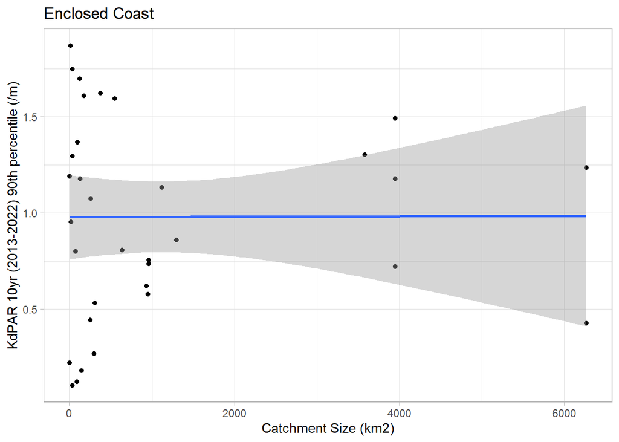

```r
p2 <- kd_metrics %>%
  mutate(Buffer_Size = Buffer_Size/1000) %>%
  filter(Buffer_Size == 10 & !is.na(KdPAR) & Metrics == 'percentile90' & CATCHMT_AR>0 & CLASS2 == 'Enclosed Coast') %>%
  ggplot(data=.,aes(x=CATCHMT_AR,y=KdPAR)) +
  geom_point() +
  geom_smooth(method = 'lm') +
  ylab('KdPAR 10yr (2013-2022) 90th percentile (/m)') + xlab('Catchment Size (km2)') +
  ggtitle('Enclosed Coast') +
  theme_light() +
  theme(legend.position = 'bottom')
p2
```

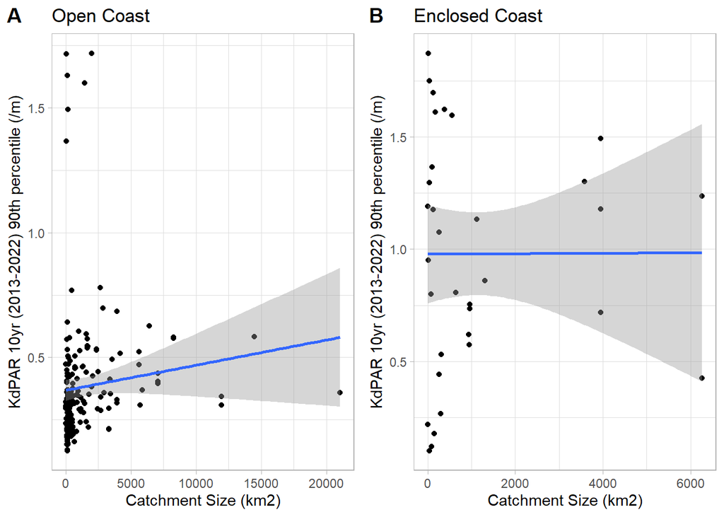

```r
figS3 <- ggarrange(p,
                     p2,
                     labels = c("A", "B"),
                     ncol = 2, nrow = 1)
figS3
```